# LDP Noun Phrases - Technical Report Markdown 2_12_2021

```python
pd.read_csv('session_3_child_data_det_noun.csv')
```

|  | Unnamed: 0 | subject | session | a_nps_counts | the_nps_counts | overlap |
| --- | --- | --- | --- | --- | --- | --- |
| 0 | 2 | 22 | 3 | 1 | 0 | 0.000000 |
| 1 | 5 | 24 | 3 | 0 | 0 | 0.000000 |
| 2 | 8 | 25 | 3 | 0 | 0 | 0.000000 |
| 3 | 11 | 27 | 3 | 0 | 0 | 0.000000 |
| 4 | 14 | 28 | 3 | 0 | 0 | 0.000000 |
| 5 | 17 | 29 | 3 | 4 | 33 | 0.000000 |
| 6 | 20 | 33 | 3 | 0 | 0 | 0.000000 |
| 7 | 23 | 37 | 3 | 0 | 0 | 0.000000 |
| 8 | 26 | 38 | 3 | 2 | 1 | 0.000000 |
| 9 | 29 | 39 | 3 | 3 | 6 | 0.000000 |
| 10 | 32 | 40 | 3 | 0 | 0 | 0.000000 |
| 11 | 35 | 42 | 3 | 0 | 0 | 0.000000 |
| 12 | 38 | 43 | 3 | 1 | 3 | 0.000000 |
| 13 | 41 | 44 | 3 | 6 | 2 | 0.000000 |
| 14 | 44 | 45 | 3 | 0 | 0 | 0.000000 |
| 15 | 47 | 47 | 3 | 0 | 0 | 0.000000 |
| 16 | 50 | 48 | 3 | 0 | 0 | 0.000000 |
| 17 | 53 | 49 | 3 | 0 | 0 | 0.000000 |
| 18 | 56 | 50 | 3 | 0 | 0 | 0.000000 |
| 19 | 59 | 51 | 3 | 0 | 0 | 0.000000 |
| 20 | 62 | 54 | 3 | 0 | 8 | 0.000000 |
| 21 | 65 | 55 | 3 | 3 | 1 | 0.000000 |
| 22 | 68 | 58 | 3 | 0 | 0 | 0.000000 |
| 23 | 71 | 59 | 3 | 0 | 0 | 0.000000 |
| 24 | 74 | 61 | 3 | 1 | 0 | 0.000000 |
| 25 | 77 | 62 | 3 | 0 | 0 | 0.000000 |
| 26 | 80 | 64 | 3 | 0 | 0 | 0.000000 |
| 27 | 83 | 65 | 3 | 0 | 0 | 0.000000 |
| 28 | 86 | 66 | 3 | 5 | 10 | 0.000000 |
| 29 | 89 | 68 | 3 | 0 | 1 | 0.000000 |
| 30 | 92 | 72 | 3 | 0 | 0 | 0.000000 |
| 31 | 95 | 73 | 3 | 0 | 0 | 0.000000 |
| 32 | 98 | 74 | 3 | 0 | 0 | 0.000000 |
| 33 | 101 | 75 | 3 | 0 | 0 | 0.000000 |
| 34 | 104 | 76 | 3 | 1 | 0 | 0.000000 |
| 35 | 107 | 77 | 3 | 0 | 0 | 0.000000 |
| 36 | 110 | 78 | 3 | 0 | 0 | 0.000000 |
| 37 | 115 | 80 | 3 | 1 | 1 | 0.000000 |
| 38 | 118 | 81 | 3 | 0 | 0 | 0.000000 |
| 39 | 121 | 82 | 3 | 5 | 2 | 0.166667 |
| 40 | 124 | 83 | 3 | 0 | 0 | 0.000000 |
| 41 | 127 | 84 | 3 | 0 | 0 | 0.000000 |
| 42 | 130 | 85 | 3 | 3 | 0 | 0.000000 |
| 43 | 135 | 88 | 3 | 1 | 1 | 1.000000 |
| 44 | 138 | 89 | 3 | 3 | 1 | 0.000000 |
| 45 | 141 | 91 | 3 | 30 | 27 | 0.057143 |
| 46 | 144 | 92 | 3 | 12 | 12 | 0.000000 |
| 47 | 147 | 100 | 3 | 6 | 11 | 0.125000 |
| 48 | 150 | 102 | 3 | 0 | 1 | 0.000000 |
| 49 | 153 | 103 | 3 | 19 | 21 | 0.030303 |
| 50 | 156 | 105 | 3 | 0 | 1 | 0.000000 |
| 51 | 159 | 106 | 3 | 0 | 0 | 0.000000 |
| 52 | 162 | 107 | 3 | 0 | 5 | 0.000000 |
| 53 | 165 | 108 | 3 | 9 | 8 | 0.250000 |
| 54 | 168 | 109 | 3 | 0 | 0 | 0.000000 |
| 55 | 171 | 110 | 3 | 4 | 0 | 0.000000 |
| 56 | 174 | 119 | 3 | 0 | 0 | 0.000000 |
| 57 | 177 | 123 | 3 | 0 | 0 | 0.000000 |
| 58 | 180 | 124 | 3 | 0 | 0 | 0.000000 |
| 59 | 183 | 125 | 3 | 7 | 2 | 0.000000 |
| 60 | 185 | 126 | 3 | 0 | 0 | 0.000000 |
| 61 | 188 | 127 | 3 | 0 | 0 | 0.000000 |

```python
pd.read_csv('session_1_parent_data_det_noun.csv')
```

|  | Unnamed: 0 | subject | session | a_nps_counts | the_nps_counts | overlap |
| --- | --- | --- | --- | --- | --- | --- |
| 0 | 0 | 22 | 1 | 41 | 76 | 0.169231 |
| 1 | 3 | 24 | 1 | 79 | 101 | 0.105882 |
| 2 | 6 | 25 | 1 | 35 | 50 | 0.125000 |
| 3 | 9 | 27 | 1 | 79 | 300 | 0.105263 |
| 4 | 12 | 28 | 1 | 40 | 123 | 0.025641 |
| 5 | 15 | 29 | 1 | 98 | 204 | 0.213592 |
| 6 | 18 | 33 | 1 | 20 | 39 | 0.034483 |
| 7 | 21 | 37 | 1 | 35 | 63 | 0.054545 |
| 8 | 24 | 38 | 1 | 44 | 94 | 0.050000 |
| 9 | 27 | 39 | 1 | 30 | 97 | 0.108696 |
| 10 | 30 | 40 | 1 | 25 | 75 | 0.033898 |
| 11 | 33 | 42 | 1 | 9 | 40 | 0.000000 |
| 12 | 36 | 43 | 1 | 51 | 59 | 0.101449 |
| 13 | 39 | 44 | 1 | 17 | 60 | 0.060606 |
| 14 | 42 | 45 | 1 | 32 | 52 | 0.000000 |
| 15 | 45 | 47 | 1 | 28 | 73 | 0.084746 |
| 16 | 48 | 48 | 1 | 44 | 90 | 0.107692 |
| 17 | 51 | 49 | 1 | 26 | 85 | 0.090909 |
| 18 | 54 | 50 | 1 | 55 | 84 | 0.037975 |
| 19 | 57 | 51 | 1 | 26 | 33 | 0.096774 |
| 20 | 60 | 54 | 1 | 29 | 72 | 0.076923 |
| 21 | 63 | 55 | 1 | 6 | 8 | 0.000000 |
| 22 | 66 | 58 | 1 | 26 | 82 | 0.102041 |
| 23 | 69 | 59 | 1 | 16 | 16 | 0.000000 |
| 24 | 72 | 61 | 1 | 7 | 10 | 0.000000 |
| 25 | 75 | 62 | 1 | 70 | 141 | 0.082569 |
| 26 | 78 | 64 | 1 | 13 | 12 | 0.000000 |
| 27 | 81 | 65 | 1 | 46 | 66 | 0.079365 |
| 28 | 84 | 66 | 1 | 32 | 67 | 0.111111 |
| 29 | 87 | 68 | 1 | 12 | 59 | 0.100000 |
| 30 | 90 | 72 | 1 | 31 | 49 | 0.024390 |
| 31 | 93 | 73 | 1 | 20 | 31 | 0.033333 |
| 32 | 96 | 74 | 1 | 20 | 40 | 0.100000 |
| 33 | 99 | 75 | 1 | 86 | 143 | 0.090090 |
| 34 | 102 | 76 | 1 | 34 | 149 | 0.107692 |
| 35 | 105 | 77 | 1 | 4 | 15 | 0.000000 |
| 36 | 108 | 78 | 1 | 26 | 114 | 0.080645 |
| 37 | 111 | 79 | 1 | 19 | 62 | 0.071429 |
| 38 | 113 | 80 | 1 | 9 | 40 | 0.000000 |
| 39 | 116 | 81 | 1 | 0 | 2 | 0.000000 |
| 40 | 119 | 82 | 1 | 14 | 60 | 0.022727 |
| 41 | 122 | 83 | 1 | 39 | 82 | 0.036585 |
| 42 | 125 | 84 | 1 | 24 | 100 | 0.033898 |
| 43 | 128 | 85 | 1 | 59 | 130 | 0.097561 |
| 44 | 131 | 87 | 1 | 5 | 31 | 0.117647 |
| 45 | 133 | 88 | 1 | 33 | 91 | 0.111111 |
| 46 | 136 | 89 | 1 | 1 | 22 | 0.090909 |
| 47 | 139 | 91 | 1 | 41 | 76 | 0.142857 |
| 48 | 142 | 92 | 1 | 43 | 70 | 0.123077 |
| 49 | 145 | 100 | 1 | 30 | 79 | 0.075000 |
| 50 | 148 | 102 | 1 | 41 | 120 | 0.106667 |
| 51 | 151 | 103 | 1 | 68 | 171 | 0.125000 |
| 52 | 154 | 105 | 1 | 31 | 94 | 0.113208 |
| 53 | 157 | 106 | 1 | 60 | 113 | 0.148936 |
| 54 | 160 | 107 | 1 | 47 | 122 | 0.171429 |
| 55 | 163 | 108 | 1 | 34 | 83 | 0.028169 |
| 56 | 166 | 109 | 1 | 41 | 107 | 0.090909 |
| 57 | 169 | 110 | 1 | 20 | 27 | 0.035714 |
| 58 | 172 | 119 | 1 | 75 | 49 | 0.160714 |
| 59 | 175 | 123 | 1 | 45 | 99 | 0.138462 |
| 60 | 178 | 124 | 1 | 17 | 49 | 0.052632 |
| 61 | 181 | 125 | 1 | 12 | 11 | 0.000000 |
| 62 | 184 | 126 | 1 | 13 | 73 | 0.025000 |
| 63 | 186 | 127 | 1 | 35 | 19 | 0.096774 |

```python
pd.read_csv('session_2_parent_data_det_noun.csv')
```

|  | Unnamed: 0 | subject | session | a_nps_counts | the_nps_counts | overlap |
| --- | --- | --- | --- | --- | --- | --- |
| 0 | 1 | 22 | 2 | 51 | 78 | 0.209677 |
| 1 | 4 | 24 | 2 | 45 | 33 | 0.076923 |
| 2 | 7 | 25 | 2 | 21 | 46 | 0.023256 |
| 3 | 10 | 27 | 2 | 95 | 275 | 0.192000 |
| 4 | 13 | 28 | 2 | 68 | 106 | 0.108696 |
| 5 | 16 | 29 | 2 | 78 | 188 | 0.177570 |
| 6 | 19 | 33 | 2 | 58 | 62 | 0.084746 |
| 7 | 22 | 37 | 2 | 35 | 75 | 0.070423 |
| 8 | 25 | 38 | 2 | 39 | 37 | 0.021739 |
| 9 | 28 | 39 | 2 | 41 | 89 | 0.071429 |
| 10 | 31 | 40 | 2 | 63 | 112 | 0.087912 |
| 11 | 34 | 42 | 2 | 28 | 90 | 0.046875 |
| 12 | 37 | 43 | 2 | 50 | 45 | 0.109091 |
| 13 | 40 | 44 | 2 | 13 | 22 | 0.062500 |
| 14 | 43 | 45 | 2 | 46 | 54 | 0.066667 |
| 15 | 46 | 47 | 2 | 27 | 53 | 0.040816 |
| 16 | 49 | 48 | 2 | 55 | 177 | 0.087912 |
| 17 | 52 | 49 | 2 | 53 | 45 | 0.131148 |
| 18 | 55 | 50 | 2 | 40 | 154 | 0.063158 |
| 19 | 58 | 51 | 2 | 23 | 65 | 0.081633 |
| 20 | 61 | 54 | 2 | 71 | 181 | 0.168224 |
| 21 | 64 | 55 | 2 | 9 | 22 | 0.058824 |
| 22 | 67 | 58 | 2 | 40 | 91 | 0.057143 |
| 23 | 70 | 59 | 2 | 13 | 10 | 0.000000 |
| 24 | 73 | 61 | 2 | 21 | 24 | 0.142857 |
| 25 | 76 | 62 | 2 | 21 | 102 | 0.070175 |
| 26 | 79 | 64 | 2 | 6 | 13 | 0.000000 |
| 27 | 82 | 65 | 2 | 79 | 143 | 0.151515 |
| 28 | 85 | 66 | 2 | 22 | 79 | 0.071429 |
| 29 | 88 | 68 | 2 | 9 | 29 | 0.000000 |
| 30 | 91 | 72 | 2 | 76 | 95 | 0.129032 |
| 31 | 94 | 73 | 2 | 31 | 27 | 0.117647 |
| 32 | 97 | 74 | 2 | 27 | 41 | 0.075000 |
| 33 | 100 | 75 | 2 | 125 | 127 | 0.145455 |
| 34 | 103 | 76 | 2 | 35 | 165 | 0.255814 |
| 35 | 106 | 77 | 2 | 5 | 5 | 0.000000 |
| 36 | 109 | 78 | 2 | 42 | 192 | 0.133333 |
| 37 | 112 | 79 | 2 | 18 | 75 | 0.071429 |
| 38 | 114 | 80 | 2 | 30 | 124 | 0.073529 |
| 39 | 117 | 81 | 2 | 5 | 1 | 0.000000 |
| 40 | 120 | 82 | 2 | 38 | 69 | 0.037736 |
| 41 | 123 | 83 | 2 | 33 | 84 | 0.087500 |
| 42 | 126 | 84 | 2 | 18 | 62 | 0.069767 |
| 43 | 129 | 85 | 2 | 76 | 238 | 0.175439 |
| 44 | 132 | 87 | 2 | 10 | 39 | 0.111111 |
| 45 | 134 | 88 | 2 | 15 | 36 | 0.035714 |
| 46 | 137 | 89 | 2 | 20 | 44 | 0.129032 |
| 47 | 140 | 91 | 2 | 87 | 181 | 0.173469 |
| 48 | 143 | 92 | 2 | 79 | 96 | 0.168831 |
| 49 | 146 | 100 | 2 | 46 | 106 | 0.074627 |
| 50 | 149 | 102 | 2 | 107 | 196 | 0.230769 |
| 51 | 152 | 103 | 2 | 60 | 169 | 0.115385 |
| 52 | 155 | 105 | 2 | 26 | 72 | 0.047619 |
| 53 | 158 | 106 | 2 | 65 | 68 | 0.093333 |
| 54 | 161 | 107 | 2 | 41 | 154 | 0.172840 |
| 55 | 164 | 108 | 2 | 38 | 80 | 0.056604 |
| 56 | 167 | 109 | 2 | 32 | 70 | 0.098361 |
| 57 | 170 | 110 | 2 | 28 | 42 | 0.065217 |
| 58 | 173 | 119 | 2 | 47 | 59 | 0.079365 |
| 59 | 176 | 123 | 2 | 12 | 23 | 0.000000 |
| 60 | 179 | 124 | 2 | 17 | 29 | 0.125000 |
| 61 | 182 | 125 | 2 | 34 | 35 | 0.020000 |
| 62 | 187 | 127 | 2 | 12 | 27 | 0.083333 |

```python
pd.read_csv('session_3_parent_data_det_noun.csv')
```

|  | Unnamed: 0 | subject | session | a_nps_counts | the_nps_counts | overlap |
| --- | --- | --- | --- | --- | --- | --- |
| 0 | 2 | 22 | 3 | 71 | 67 | 0.115942 |
| 1 | 5 | 24 | 3 | 40 | 60 | 0.080000 |
| 2 | 8 | 25 | 3 | 31 | 84 | 0.092308 |
| 3 | 11 | 27 | 3 | 96 | 253 | 0.139535 |
| 4 | 14 | 28 | 3 | 52 | 83 | 0.071429 |
| 5 | 17 | 29 | 3 | 82 | 91 | 0.151163 |
| 6 | 20 | 33 | 3 | 40 | 74 | 0.056604 |
| 7 | 23 | 37 | 3 | 23 | 27 | 0.031250 |
| 8 | 26 | 38 | 3 | 41 | 92 | 0.045977 |
| 9 | 29 | 39 | 3 | 36 | 63 | 0.047619 |
| 10 | 32 | 40 | 3 | 28 | 71 | 0.061224 |
| 11 | 35 | 42 | 3 | 31 | 117 | 0.080645 |
| 12 | 38 | 43 | 3 | 48 | 91 | 0.097222 |
| 13 | 41 | 44 | 3 | 26 | 56 | 0.102564 |
| 14 | 44 | 45 | 3 | 41 | 58 | 0.075472 |
| 15 | 47 | 47 | 3 | 47 | 72 | 0.062500 |
| 16 | 50 | 48 | 3 | 42 | 148 | 0.132353 |
| 17 | 53 | 49 | 3 | 16 | 57 | 0.041667 |
| 18 | 56 | 50 | 3 | 44 | 117 | 0.022989 |
| 19 | 59 | 51 | 3 | 20 | 55 | 0.122449 |
| 20 | 62 | 54 | 3 | 53 | 130 | 0.090000 |
| 21 | 65 | 55 | 3 | 7 | 13 | 0.222222 |
| 22 | 68 | 58 | 3 | 51 | 123 | 0.172414 |
| 23 | 71 | 59 | 3 | 13 | 12 | 0.000000 |
| 24 | 74 | 61 | 3 | 10 | 41 | 0.037037 |
| 25 | 77 | 62 | 3 | 26 | 88 | 0.061538 |
| 26 | 80 | 64 | 3 | 0 | 4 | 0.000000 |
| 27 | 83 | 65 | 3 | 100 | 174 | 0.211009 |
| 28 | 86 | 66 | 3 | 20 | 54 | 0.026316 |
| 29 | 89 | 68 | 3 | 15 | 66 | 0.060606 |
| 30 | 92 | 72 | 3 | 53 | 80 | 0.033333 |
| 31 | 95 | 73 | 3 | 27 | 29 | 0.000000 |
| 32 | 98 | 74 | 3 | 6 | 8 | 0.125000 |
| 33 | 101 | 75 | 3 | 102 | 108 | 0.115044 |
| 34 | 104 | 76 | 3 | 37 | 251 | 0.107843 |
| 35 | 107 | 77 | 3 | 4 | 14 | 0.000000 |
| 36 | 110 | 78 | 3 | 41 | 101 | 0.080460 |
| 37 | 115 | 80 | 3 | 23 | 56 | 0.102564 |
| 38 | 118 | 81 | 3 | 10 | 10 | 0.000000 |
| 39 | 121 | 82 | 3 | 22 | 60 | 0.042553 |
| 40 | 124 | 83 | 3 | 19 | 94 | 0.070175 |
| 41 | 127 | 84 | 3 | 50 | 109 | 0.080460 |
| 42 | 130 | 85 | 3 | 153 | 336 | 0.126506 |
| 43 | 135 | 88 | 3 | 15 | 41 | 0.033333 |
| 44 | 138 | 89 | 3 | 20 | 13 | 0.000000 |
| 45 | 141 | 91 | 3 | 60 | 71 | 0.111111 |
| 46 | 144 | 92 | 3 | 90 | 108 | 0.168675 |
| 47 | 147 | 100 | 3 | 30 | 140 | 0.105263 |
| 48 | 150 | 102 | 3 | 84 | 149 | 0.148936 |
| 49 | 153 | 103 | 3 | 90 | 157 | 0.087591 |
| 50 | 156 | 105 | 3 | 74 | 80 | 0.087500 |
| 51 | 159 | 106 | 3 | 50 | 88 | 0.064103 |
| 52 | 162 | 107 | 3 | 39 | 120 | 0.164384 |
| 53 | 165 | 108 | 3 | 78 | 64 | 0.098765 |
| 54 | 168 | 109 | 3 | 41 | 89 | 0.055556 |
| 55 | 171 | 110 | 3 | 23 | 50 | 0.051282 |
| 56 | 174 | 119 | 3 | 86 | 91 | 0.137500 |
| 57 | 177 | 123 | 3 | 28 | 23 | 0.060606 |
| 58 | 180 | 124 | 3 | 25 | 86 | 0.027027 |
| 59 | 183 | 125 | 3 | 1 | 1 | 0.000000 |
| 60 | 185 | 126 | 3 | 23 | 48 | 0.025641 |
| 61 | 188 | 127 | 3 | 34 | 31 | 0.000000 |

```python
### t-tests performed to determine differences between a versus the usage within sessions ###
```

```python
from scipy import stats

t_test_det_s1 = stats.ttest_rel(pd.read_csv('session_1_parent_data_det_noun.csv').a_nps_counts, pd.read_csv('session_1_parent_data_det_noun.csv').the_nps_counts)

t_test_det_s2 = stats.ttest_rel(pd.read_csv('session_2_parent_data_det_noun.csv').a_nps_counts, pd.read_csv('session_2_parent_data_det_noun.csv').the_nps_counts)

t_test_det_s3 = stats.ttest_rel(pd.read_csv('session_3_parent_data_det_noun.csv').a_nps_counts, pd.read_csv('session_3_parent_data_det_noun.csv').the_nps_counts)


print(t_test_det_s1, t_test_det_s2, t_test_det_s3)
```

```
Ttest_relResult(statistic=-9.105963271695037, pvalue=4.2469782755444854e-13) Ttest_relResult(statistic=-7.573332399846721, pvalue=2.178268373186091e-10) Ttest_relResult(statistic=-7.375591785905929, pvalue=5.232797286111117e-10)
```

```python
# N-gram (Bigrams) models were also generated for each parent and typcial child for sessions 1-8 to assess noun overlap
### for simplicity sake those models are contained and saved in a separate notebook
```

Yang (2013) calculates the expected value of overlap for a sample of Det-N combinations, under the assumption that the determiner and nouns, as syntactic categories, combine productively and fully interchangeably. Let S be the size of the sample, the token frequency sum of all Det-N pairs, and N be the number of unique noun types. We refer the reader to that paper for details of the mathematical formulation but will highlight two conceptual points central to that study.

First, because noun frequencies can be approximated by Zipf’s Law, the rth most frequent noun will have the expected frequency of S/rHN, where HN is the harmonic number 1+1/2+1/3+…+1/N. While this statistical property may not strictly hold in smaller corpora such as those in language acquisition studies (e.g., McCauley & Christiansen 2014, Pine et al. 2013), the accuracy of Zipf’s Law has been extensively documented in numerous large-scale corpus studies (e.g., Baroni, 2009), and thus, we argue, serves as a better proxy for “true” word frequencies in any corpus than the actual empirical frequencies. It follows that only nouns with a rank lower than S/HN, out of the N nouns, can be expected to have overlap, under the assumption that the determiner and nouns combine productively. Given the slow growth of HN (approximately lnN), the overlap value of a sample will be strongly correlated with S/N, the token/type ratio of the nouns in the corpus. As shown in Valian et al. (2009) and Analysis 1, the overlap values of mothers and children do not differ in samples stratified by frequency. Second, Yang (2013) takes into account the fact that different nouns favor one determiner over the other – there is a determiner bias (B). We quantify the bias toward one or another determiner for each speaker. For each noun in a corpus, we count and compare the number of times the noun appears with a/an and the number of times it occurs with the. The ratio of the larger number of determiners to the total number is the measure of determiner bias. Thus, if a noun has 10 uses of determiners, 5 of each type, the determiner bias is .50. If all 10 uses are a single determiner type, the value would be 1. Determiner bias values can range from .50 to 1.0. The closer the value is to 1.0, the larger the bias. The determiner bias is summed over all nouns for a speaker and then divided by the total number of times that the speaker used those nouns to provide a quantitative measure of determiner bias. For the purpose of overlap calculation, it does not matter which determiner is favored, only that one of them is. Yang (2013) documented this for the one-million-word Brown corpus: the 6,000 annotated singular nouns have an average bias value of 0.79. In the much larger Corpus of Contemporary American English (COCA), the overall determiner bias is 0.82, even if we only include the 19,480 singular common noun types used at least twice: only 1,380 (7%) of these have no bias—a balanced use of the and a. (We thank Martin Chodorow for the COCA analysis.)

The three variables, i.e., the number of noun tokens (S), the number of Noun types (N), and determiner bias (B), were used to create predicted overlap values for each child and each mother (see Yang, 2013 for the relevant equations). We compared the predicted overlap values with the actual observed overlap values for each child and mother.

In addition to computing overall overlap values from all files separately for child and mother, we computed overlap values by phase. Phase was defined as in Pine et al. (2013); see Analysis 3 for details. Here we focus on Phase 1, which represents the earliest longitudinal data starting at age 2;0, the stage during which children produced no fewer than 50 unique Det-N pairs. The children’s Det-N combinations were extracted and the overlap values for the twelve corpora were computed and compared to the predicted values, again using the three variables of S, N, and B.

### Yang Valian 2020 Analysis 1&2 Replication

```python
import pandas as pd
```

```python
pcg_1_3 = pd.read_csv("revised_parent_sessions_counts_1_3.csv")
pcg_4_8 = pd.read_csv("revised_parent_sessions_counts_4_8.csv")
chi_1_3 = pd.read_csv("revised_child_sessions_counts_1_3.csv")
chi_4_8 = pd.read_csv("revised_child_sessions_counts_4_8.csv")
```

```python
len(pcg_1_3)
```

```
33730
```

```python
pdf = pcg_4_8[pcg_4_8['subject'] == 22]['index'].dropna().tolist()
pdf = [x for x in pdf if (len(x.split()) == 2) and (x.split()[0] == 'a' or x.split()[0] == 'the')]
len(pdf)
```

```
480
```

```python
### list of unique subjects of typically developing kids in the LDP
subjects = list(set(pcg_1_3.subject.tolist()))

import math

def ldp_yang_analysis_1_2(pdf, sub, session, parent_child):


    """
    REPLICATION FOR YANG & VALIAN 2020 PAPER ANALYSES 1 & 2 ON LANGUAGE DEVELOPMENT PROJECT DATA

    Must pass dataframe with sunject, session, and parent or child in the form of "parent_det_str" or "child_det_str"

    Let S be the size of the sample, the token frequency sum of all Det-N pairs, and N be the number of unique noun types.
    The determiner bias is summed over all nouns for a speaker and then divided by the total number of times that
    the speaker used those nouns to provide a quantitative measure of determiner bias.

    """
    result = []

    ###format dataframe to arguments passed to the function and cast to list

    pdf = pdf[(pdf['subject'] == sub) & (pdf['session'] == session)][f'{parent_child}'].tolist()

    ###check to ensure determiner type is of length 2

    pdf = [x for x in pdf if (x != '') and (len(x.split()) == 2)]



    def Harmonic(n):
        s=0
        for i in range(1, n+1):
            s+=1.0/i
        return s

    def expected_overlap(N, S, r, b):
        hN = Harmonic(N)
        p = 1.0/(r*hN)
        eo = 1 - sum( [ math.pow((p*di+1.0-p), S) for di in [b, 1.0-b] ] ) + math.pow(1-p, S)
        assert eo>0, '%d, %.6f'%(r, eo)
        return eo

    def average_expected_overlap(N, S, b):
        sumo = 0
        for r in range(1, N+1):
            sumo += expected_overlap(N, S, r, b)
        return sumo/N

    def freqcounts(word, data):
        ccc = 0
        for i in range(0, len(data)):
            if word == data[i].split()[1]:
                ccc += 1
        return ccc

    def uniqwords(data):
        ccc = 0
        uniqw = []
        for i in range(0, len(data)):
            nnn = data[i].split()[1]
            if nnn not in uniqw:
                uniqw.append(nnn)
                ccc += 1
        return ccc

    def calculate_overlap(data): # returns s, n, and empirical overlap
        result = []
        result.append(len(data))

        uniqnoun = []
        for i in range(0, len(data)):
            nnn = data[i].split()[1]
            if nnn not in uniqnoun:
                uniqnoun.append(nnn)
        result.append(len(uniqnoun))

        both = 0 # counts of nouns that have overlap
        for i in range(0, len(uniqnoun)):
            a = 0
            the = 0
            for j in range(0, len(data)):
                if uniqnoun[i] == data[j].split()[1]:
                    if data[j].split()[0] == 'a':
                        a = 1
                    if data[j].split()[0] == 'the':
                        the = 1
            if a == 1 and the == 1:
                both += 1

        result.append(both)

        return result

    def find_bias(data):

        uniqw = []
        for i in range(0, len(data)):
            nnn = data[i].split()[1]
            if nnn not in uniqw:
                uniqw.append(nnn)


        big = 0
        small = 0
        for i in range(0, len(uniqw)):
            a = 0
            the = 0
            for j in range(0, len(data)):
                if uniqw[i] == data[j].split()[1]:
                    if data[j].split()[0] == 'a':
                        a += 1
                    else:
                        the +=1
            if a >= the:
                big += a
                small += the
            else:
                big += the
                small += a
        return float(big)/float(big+small)

    p_tmp = calculate_overlap(pdf)
    p_S = int(p_tmp[0])
    p_N = int(p_tmp[1])
    p_O = int(p_tmp[2])
    p_bias = find_bias(pdf)


    print(sub, session, p_N, p_S, ("%.3f" % p_bias), ("%.3f" % (float(p_S)/float(p_N))),  ("%.3f" % (float(p_O)/float(p_N))), ("%.3f" % average_expected_overlap(p_N, p_S, p_bias)))

    return [sub, session, p_N, p_S, p_bias, (float(p_S)/float(p_N)), (float(p_O)/float(p_N)), average_expected_overlap(p_N, p_S, p_bias)]
```

```python
# print("Subject, Unique Types, Total # Nouns, Bias, Token/Type Ratio, Observed, Expected")
# result = []
# for sub in subjects:
#     try:
#         result.append(yang_analysis_1_2(pcg_4_8, sub))
#     except:
#         print('failed assertion error:', sub)
```

### LDP YANG ANALYSIS 1-2 Table Sessions 1-3 PCG

```python
### Sessions 1-3 PCG
pd.set_option('display.max_columns', None)  # or 1000
pd.set_option('display.max_rows', None)  # or 1000
pd.read_csv('ldp_parent_yang_analysis_1_2_sessions_1_3.csv').drop(columns=['Unnamed: 0'])
```

|  | Subject | Unique Types | Total # Nouns | Bias | Token/Type Ratio | Observed | Expected |
| --- | --- | --- | --- | --- | --- | --- | --- |
| 0 | 22 | 273 | 717 | 0.892608 | 2.626374 | 0.106227 | 0.127356 |
| 1 | 24 | 245 | 705 | 0.912057 | 2.877551 | 0.102041 | 0.122880 |
| 2 | 25 | 227 | 645 | 0.925581 | 2.841410 | 0.079295 | 0.109438 |
| 3 | 27 | 430 | 2004 | 0.918663 | 4.660465 | 0.139535 | 0.165569 |
| 4 | 28 | 418 | 1077 | 0.917363 | 2.576555 | 0.066986 | 0.099442 |
| 5 | 29 | 318 | 1298 | 0.886749 | 4.081761 | 0.144654 | 0.190165 |
| 6 | 33 | 237 | 801 | 0.945069 | 3.379747 | 0.054852 | 0.102654 |
| 7 | 37 | 258 | 666 | 0.939940 | 2.581395 | 0.050388 | 0.084664 |
| 8 | 38 | 302 | 875 | 0.930286 | 2.897351 | 0.076159 | 0.102556 |
| 9 | 39 | 200 | 848 | 0.950472 | 4.240000 | 0.050000 | 0.119066 |
| 10 | 40 | 252 | 867 | 0.943483 | 3.440476 | 0.083333 | 0.105631 |
| 11 | 42 | 216 | 736 | 0.967391 | 3.407407 | 0.050926 | 0.070921 |
| 12 | 43 | 267 | 708 | 0.892655 | 2.651685 | 0.097378 | 0.128805 |
| 13 | 44 | 164 | 510 | 0.962745 | 3.109756 | 0.036585 | 0.074665 |
| 14 | 45 | 221 | 538 | 0.944238 | 2.434389 | 0.045249 | 0.077469 |
| 15 | 47 | 263 | 651 | 0.932412 | 2.475285 | 0.049430 | 0.088402 |
| 16 | 48 | 285 | 1123 | 0.947462 | 3.940351 | 0.091228 | 0.111350 |
| 17 | 49 | 302 | 715 | 0.931469 | 2.367550 | 0.062914 | 0.084151 |
| 18 | 50 | 370 | 1080 | 0.927778 | 2.918919 | 0.075676 | 0.103121 |
| 19 | 51 | 204 | 612 | 0.933007 | 3.000000 | 0.058824 | 0.108302 |
| 20 | 54 | 344 | 1142 | 0.907180 | 3.319767 | 0.125000 | 0.138491 |
| 21 | 55 | 80 | 151 | 0.960265 | 1.887500 | 0.037500 | 0.052169 |
| 22 | 58 | 249 | 933 | 0.922830 | 3.746988 | 0.088353 | 0.141844 |
| 23 | 59 | 108 | 254 | 0.972441 | 2.351852 | 0.018519 | 0.046863 |
| 24 | 61 | 116 | 258 | 0.949612 | 2.224138 | 0.051724 | 0.071422 |
| 25 | 62 | 346 | 993 | 0.941591 | 2.869942 | 0.069364 | 0.088134 |
| 26 | 64 | 63 | 127 | 0.984252 | 2.015873 | 0.000000 | 0.025153 |
| 27 | 65 | 314 | 1083 | 0.885503 | 3.449045 | 0.130573 | 0.165949 |
| 28 | 66 | 180 | 604 | 0.942053 | 3.355556 | 0.066667 | 0.109835 |
| 29 | 68 | 169 | 550 | 0.970909 | 3.254438 | 0.011834 | 0.064033 |
| 30 | 72 | 268 | 1155 | 0.917749 | 4.309701 | 0.067164 | 0.165487 |
| 31 | 73 | 175 | 394 | 0.928934 | 2.251429 | 0.028571 | 0.088444 |
| 32 | 74 | 136 | 326 | 0.911043 | 2.397059 | 0.088235 | 0.113468 |
| 33 | 75 | 408 | 1602 | 0.900749 | 3.926471 | 0.115196 | 0.163982 |
| 34 | 76 | 226 | 1053 | 0.951567 | 4.659292 | 0.097345 | 0.125209 |
| 35 | 77 | 80 | 144 | 0.993056 | 1.800000 | 0.000000 | 0.010150 |
| 36 | 78 | 298 | 1087 | 0.957682 | 3.647651 | 0.057047 | 0.088272 |
| 37 | 79 | 156 | 465 | 0.972043 | 2.980769 | 0.044872 | 0.057616 |
| 38 | 80 | 170 | 535 | 0.932710 | 3.147059 | 0.064706 | 0.116194 |
| 39 | 82 | 216 | 624 | 0.943910 | 2.888889 | 0.050926 | 0.091451 |
| 40 | 83 | 298 | 736 | 0.936141 | 2.469799 | 0.073826 | 0.083371 |
| 41 | 84 | 271 | 887 | 0.942503 | 3.273063 | 0.070111 | 0.101303 |
| 42 | 85 | 470 | 1991 | 0.908589 | 4.236170 | 0.123404 | 0.163079 |
| 43 | 87 | 85 | 203 | 0.970443 | 2.388235 | 0.035294 | 0.051569 |
| 44 | 88 | 169 | 452 | 0.940265 | 2.674556 | 0.053254 | 0.092047 |
| 45 | 89 | 104 | 290 | 0.955172 | 2.788462 | 0.048077 | 0.082132 |
| 46 | 91 | 362 | 1244 | 0.913183 | 3.436464 | 0.110497 | 0.135692 |
| 47 | 92 | 276 | 1061 | 0.892554 | 3.844203 | 0.130435 | 0.177966 |
| 48 | 100 | 249 | 1070 | 0.958879 | 4.297189 | 0.060241 | 0.102300 |
| 49 | 102 | 316 | 1273 | 0.891595 | 4.028481 | 0.139241 | 0.183097 |
| 50 | 103 | 404 | 1366 | 0.898243 | 3.381188 | 0.108911 | 0.146478 |
| 51 | 105 | 263 | 1013 | 0.948667 | 3.851711 | 0.079848 | 0.108418 |
| 52 | 106 | 353 | 1054 | 0.911765 | 2.985836 | 0.079320 | 0.121423 |
| 53 | 107 | 262 | 1031 | 0.936954 | 3.935115 | 0.103053 | 0.127930 |
| 54 | 108 | 284 | 886 | 0.926637 | 3.119718 | 0.066901 | 0.114513 |
| 55 | 109 | 334 | 822 | 0.930657 | 2.461078 | 0.071856 | 0.086835 |
| 56 | 110 | 191 | 513 | 0.939571 | 2.685864 | 0.031414 | 0.091712 |
| 57 | 119 | 298 | 1046 | 0.889101 | 3.510067 | 0.077181 | 0.166238 |
| 58 | 123 | 186 | 525 | 0.895238 | 2.822581 | 0.080645 | 0.140734 |
| 59 | 124 | 201 | 610 | 0.963934 | 3.034826 | 0.034826 | 0.069440 |
| 60 | 125 | 137 | 203 | 0.950739 | 1.481752 | 0.007299 | 0.046017 |
| 61 | 126 | 151 | 359 | 0.958217 | 2.377483 | 0.033113 | 0.063904 |
| 62 | 127 | 198 | 524 | 0.929389 | 2.646465 | 0.030303 | 0.100645 |

### LDP YANG ANALYSIS 1-2 Table Sessions 4-8 PCG

```python
### Sessions 4-8 PCG
pd.set_option('display.max_columns', None)  # or 1000
pd.set_option('display.max_rows', None)  # or 1000
pd.read_csv('ldp_parent_yang_analysis_1_2_sessions_4_8.csv').drop(columns=['Unnamed: 0'])
```

|  | Subject | Unique Types | Total # Nouns | Bias | Token/Type Ratio | Observed | Expected |
| --- | --- | --- | --- | --- | --- | --- | --- |
| 0 | 22 | 358 | 795 | 0.928302 | 2.220670 | 0.108939 | 0.080087 |
| 1 | 24 | 287 | 770 | 0.905195 | 2.682927 | 0.170732 | 0.118817 |
| 2 | 25 | 222 | 466 | 0.927039 | 2.099099 | 0.108108 | 0.081794 |
| 3 | 27 | 341 | 1077 | 0.895079 | 3.158358 | 0.217009 | 0.143742 |
| 4 | 28 | 269 | 556 | 0.924460 | 2.066914 | 0.107807 | 0.080584 |
| 5 | 29 | 324 | 782 | 0.892583 | 2.413580 | 0.163580 | 0.115338 |
| 6 | 33 | 156 | 368 | 0.959239 | 2.358974 | 0.083333 | 0.061980 |
| 7 | 37 | 235 | 502 | 0.950199 | 2.136170 | 0.093617 | 0.062473 |
| 8 | 38 | 205 | 428 | 0.955607 | 2.087805 | 0.063415 | 0.056962 |
| 9 | 39 | 127 | 321 | 0.943925 | 2.527559 | 0.118110 | 0.086491 |
| 10 | 40 | 223 | 472 | 0.925847 | 2.116592 | 0.112108 | 0.083338 |
| 11 | 42 | 295 | 634 | 0.913249 | 2.149153 | 0.138983 | 0.090921 |
| 12 | 43 | 302 | 608 | 0.907895 | 2.013245 | 0.139073 | 0.088835 |
| 13 | 44 | 83 | 155 | 0.974194 | 1.867470 | 0.048193 | 0.035609 |
| 14 | 45 | 283 | 527 | 0.931689 | 1.862191 | 0.102473 | 0.067524 |
| 15 | 47 | 287 | 612 | 0.903595 | 2.132404 | 0.142857 | 0.097312 |
| 16 | 48 | 329 | 1019 | 0.909715 | 3.097264 | 0.151976 | 0.128570 |
| 17 | 49 | 377 | 894 | 0.927293 | 2.371353 | 0.127321 | 0.085412 |
| 18 | 50 | 240 | 509 | 0.935167 | 2.120833 | 0.112500 | 0.075137 |
| 19 | 51 | 249 | 484 | 0.917355 | 1.943775 | 0.120482 | 0.081809 |
| 20 | 54 | 356 | 777 | 0.913771 | 2.182584 | 0.146067 | 0.089651 |
| 21 | 55 | 83 | 159 | 0.987421 | 1.915663 | 0.024096 | 0.019100 |
| 22 | 58 | 345 | 703 | 0.910384 | 2.037681 | 0.142029 | 0.086676 |
| 23 | 59 | 57 | 127 | 0.937008 | 2.228070 | 0.052632 | 0.092221 |
| 24 | 61 | 162 | 395 | 0.931646 | 2.438272 | 0.123457 | 0.093614 |
| 25 | 62 | 322 | 852 | 0.909624 | 2.645963 | 0.152174 | 0.111940 |
| 26 | 64 | 81 | 112 | 0.964286 | 1.382716 | 0.049383 | 0.034227 |
| 27 | 65 | 304 | 626 | 0.904153 | 2.059211 | 0.138158 | 0.093127 |
| 28 | 66 | 264 | 732 | 0.915301 | 2.772727 | 0.136364 | 0.114711 |
| 29 | 68 | 159 | 330 | 0.936364 | 2.075472 | 0.094340 | 0.076557 |
| 30 | 72 | 283 | 851 | 0.910693 | 3.007067 | 0.162544 | 0.126751 |
| 31 | 73 | 122 | 242 | 0.929752 | 1.983607 | 0.073770 | 0.081509 |
| 32 | 74 | 180 | 366 | 0.942623 | 2.033333 | 0.094444 | 0.068470 |
| 33 | 75 | 426 | 1228 | 0.880293 | 2.882629 | 0.183099 | 0.140144 |
| 34 | 76 | 48 | 112 | 0.946429 | 2.333333 | 0.062500 | 0.086614 |
| 35 | 77 | 67 | 106 | 0.952830 | 1.582090 | 0.074627 | 0.050762 |
| 36 | 78 | 280 | 819 | 0.916972 | 2.925000 | 0.142857 | 0.117861 |
| 37 | 79 | 275 | 708 | 0.918079 | 2.574545 | 0.149091 | 0.104242 |
| 38 | 80 | 170 | 321 | 0.934579 | 1.888235 | 0.100000 | 0.070756 |
| 39 | 81 | 133 | 206 | 0.927184 | 1.548872 | 0.097744 | 0.065061 |
| 40 | 82 | 253 | 541 | 0.920518 | 2.138340 | 0.102767 | 0.086904 |
| 41 | 83 | 234 | 453 | 0.949227 | 1.935897 | 0.076923 | 0.057705 |
| 42 | 84 | 230 | 467 | 0.895075 | 2.030435 | 0.165217 | 0.101309 |
| 43 | 85 | 337 | 1049 | 0.910391 | 3.112760 | 0.172107 | 0.128103 |
| 44 | 87 | 69 | 119 | 0.957983 | 1.724638 | 0.057971 | 0.050371 |
| 45 | 88 | 201 | 351 | 0.914530 | 1.746269 | 0.114428 | 0.077793 |
| 46 | 89 | 112 | 221 | 0.954751 | 1.973214 | 0.080357 | 0.058641 |
| 47 | 91 | 203 | 375 | 0.957333 | 1.847291 | 0.064039 | 0.049098 |
| 48 | 92 | 459 | 1209 | 0.885856 | 2.633987 | 0.185185 | 0.124199 |
| 49 | 100 | 231 | 586 | 0.902730 | 2.536797 | 0.186147 | 0.118206 |
| 50 | 102 | 295 | 868 | 0.927419 | 2.942373 | 0.118644 | 0.107291 |
| 51 | 103 | 365 | 738 | 0.907859 | 2.021918 | 0.131507 | 0.087055 |
| 52 | 105 | 291 | 719 | 0.924896 | 2.470790 | 0.140893 | 0.093822 |
| 53 | 106 | 220 | 450 | 0.924444 | 2.045455 | 0.118182 | 0.081919 |
| 54 | 107 | 385 | 1327 | 0.865109 | 3.446753 | 0.205195 | 0.178854 |
| 55 | 108 | 362 | 705 | 0.900709 | 1.947514 | 0.127072 | 0.088487 |
| 56 | 109 | 239 | 578 | 0.927336 | 2.418410 | 0.138075 | 0.092204 |
| 57 | 110 | 37 | 68 | 0.941176 | 1.837838 | 0.081081 | 0.074907 |
| 58 | 119 | 274 | 574 | 0.928571 | 2.094891 | 0.120438 | 0.078258 |
| 59 | 123 | 152 | 276 | 0.927536 | 1.815789 | 0.125000 | 0.074457 |
| 60 | 124 | 147 | 241 | 0.950207 | 1.639456 | 0.068027 | 0.051010 |
| 61 | 125 | 322 | 572 | 0.928322 | 1.776398 | 0.105590 | 0.065729 |
| 62 | 126 | 147 | 328 | 0.966463 | 2.231293 | 0.054422 | 0.050662 |
| 63 | 127 | 209 | 355 | 0.963380 | 1.698565 | 0.038278 | 0.039933 |

```python
### LDP YANG ANALYSIS 1-2 Child Sessions 1-3
```

```python
### Sessions 1-3 CHI
pd.set_option('display.max_columns', None)  # or 1000
pd.set_option('display.max_rows', None)  # or 1000
pd.read_csv('ldp_child_yang_analysis_1_2_sessions_1_3.csv').drop(columns=['Unnamed: 0'])
```

|  | Subject | Unique Types | Total # Nouns | Bias | Token/Type Ratio | Observed | Expected |
| --- | --- | --- | --- | --- | --- | --- | --- |
| 0 | 24 | 2 | 3 | 1.000000 | 1.500000 | 0.000000 | 2.012279e-16 |
| 1 | 29 | 26 | 78 | 0.987179 | 3.000000 | 0.038462 | 3.318122e-02 |
| 2 | 33 | 3 | 4 | 1.000000 | 1.333333 | 0.000000 | 1.734723e-16 |
| 3 | 37 | 2 | 16 | 1.000000 | 8.000000 | 0.000000 | 9.554585e-16 |
| 4 | 38 | 18 | 29 | 0.965517 | 1.611111 | 0.000000 | 4.203216e-02 |
| 5 | 44 | 29 | 129 | 0.961240 | 4.448276 | 0.034483 | 1.307137e-01 |
| 6 | 55 | 12 | 17 | 0.941176 | 1.416667 | 0.000000 | 5.933491e-02 |
| 7 | 61 | 7 | 19 | 0.947368 | 2.714286 | 0.000000 | 1.157780e-01 |
| 8 | 66 | 25 | 131 | 0.984733 | 5.240000 | 0.000000 | 6.957479e-02 |
| 9 | 68 | 5 | 11 | 1.000000 | 2.200000 | 0.000000 | 5.375041e-16 |
| 10 | 76 | 3 | 4 | 1.000000 | 1.333333 | 0.000000 | 1.734723e-16 |
| 11 | 80 | 8 | 16 | 0.937500 | 2.000000 | 0.000000 | 9.542789e-02 |
| 12 | 81 | 2 | 3 | 1.000000 | 1.500000 | 0.000000 | 2.012279e-16 |
| 13 | 82 | 30 | 47 | 0.957447 | 1.566667 | 0.033333 | 4.833146e-02 |
| 14 | 85 | 18 | 31 | 0.935484 | 1.722222 | 0.000000 | 7.934781e-02 |
| 15 | 88 | 12 | 40 | 0.950000 | 3.333333 | 0.083333 | 1.322110e-01 |
| 16 | 91 | 107 | 531 | 0.964218 | 4.962617 | 0.037383 | 1.163931e-01 |
| 17 | 92 | 55 | 93 | 0.924731 | 1.690909 | 0.000000 | 8.054072e-02 |
| 18 | 100 | 53 | 174 | 0.982759 | 3.283019 | 0.018868 | 4.633329e-02 |
| 19 | 102 | 2 | 3 | 1.000000 | 1.500000 | 0.000000 | 2.012279e-16 |
| 20 | 103 | 68 | 122 | 0.918033 | 1.794118 | 0.029412 | 8.898830e-02 |
| 21 | 108 | 28 | 83 | 0.915663 | 2.964286 | 0.071429 | 1.641257e-01 |
| 22 | 110 | 24 | 47 | 0.957447 | 1.958333 | 0.000000 | 6.269792e-02 |
| 23 | 125 | 13 | 50 | 0.860000 | 3.846154 | 0.076923 | 3.223040e-01 |
| 24 | 127 | 6 | 30 | 0.966667 | 5.000000 | 0.000000 | 1.446003e-01 |

```python
### LDP YANG ANALYSIS 1-2 Child Sessions 4-8
```

```python
### Sessions 1-3 CHI
pd.set_option('display.max_columns', None)  # or 1000
pd.set_option('display.max_rows', None)  # or 1000
pd.read_csv('ldp_child_yang_analysis_1_2_sessions_4_8.csv').drop(columns=['Unnamed: 0'])
```

|  | Subject | Unique Types | Total # Nouns | Bias | Token/Type Ratio | Observed | Expected |
| --- | --- | --- | --- | --- | --- | --- | --- |
| 0 | 22 | 177 | 326 | 0.914110 | 1.841808 | 0.112994 | 0.083507 |
| 1 | 24 | 145 | 327 | 0.911315 | 2.255172 | 0.131034 | 0.106085 |
| 2 | 25 | 68 | 163 | 0.901840 | 2.397059 | 0.147059 | 0.133485 |
| 3 | 27 | 51 | 79 | 0.936709 | 1.549020 | 0.078431 | 0.064608 |
| 4 | 28 | 73 | 182 | 0.862637 | 2.493151 | 0.205479 | 0.170678 |
| 5 | 29 | 225 | 515 | 0.900971 | 2.288889 | 0.142222 | 0.109253 |
| 6 | 33 | 81 | 178 | 0.938202 | 2.197531 | 0.111111 | 0.086070 |
| 7 | 37 | 96 | 156 | 0.961538 | 1.625000 | 0.062500 | 0.042784 |
| 8 | 38 | 104 | 215 | 0.874419 | 2.067308 | 0.144231 | 0.129189 |
| 9 | 39 | 123 | 265 | 0.883019 | 2.154472 | 0.162602 | 0.125224 |
| 10 | 40 | 109 | 155 | 0.961290 | 1.422018 | 0.055046 | 0.036998 |
| 11 | 42 | 76 | 139 | 0.920863 | 1.828947 | 0.118421 | 0.087198 |
| 12 | 43 | 142 | 313 | 0.942492 | 2.204225 | 0.084507 | 0.076326 |
| 13 | 44 | 85 | 145 | 0.924138 | 1.705882 | 0.129412 | 0.077850 |
| 14 | 45 | 174 | 299 | 0.936455 | 1.718391 | 0.103448 | 0.063038 |
| 15 | 47 | 121 | 186 | 0.940860 | 1.537190 | 0.090909 | 0.055813 |
| 16 | 48 | 115 | 217 | 0.930876 | 1.886957 | 0.113043 | 0.077333 |
| 17 | 49 | 82 | 134 | 0.902985 | 1.634146 | 0.121951 | 0.089591 |
| 18 | 50 | 148 | 309 | 0.899676 | 2.087838 | 0.114865 | 0.107088 |
| 19 | 51 | 120 | 205 | 0.897561 | 1.708333 | 0.141667 | 0.092424 |
| 20 | 54 | 179 | 301 | 0.903654 | 1.681564 | 0.122905 | 0.082773 |
| 21 | 55 | 61 | 85 | 0.964706 | 1.393443 | 0.049180 | 0.034714 |
| 22 | 58 | 125 | 219 | 0.931507 | 1.752000 | 0.112000 | 0.070724 |
| 23 | 59 | 63 | 122 | 0.950820 | 1.936508 | 0.079365 | 0.065198 |
| 24 | 61 | 90 | 168 | 0.898810 | 1.866667 | 0.100000 | 0.103681 |
| 25 | 62 | 77 | 128 | 0.890625 | 1.662338 | 0.142857 | 0.099858 |
| 26 | 64 | 9 | 12 | 0.833333 | 1.333333 | 0.222222 | 0.133016 |
| 27 | 65 | 151 | 258 | 0.949612 | 1.708609 | 0.086093 | 0.053487 |
| 28 | 66 | 123 | 240 | 0.887500 | 1.951220 | 0.146341 | 0.111294 |
| 29 | 68 | 45 | 71 | 0.971831 | 1.577778 | 0.044444 | 0.033065 |
| 30 | 72 | 105 | 195 | 0.938462 | 1.857143 | 0.104762 | 0.070581 |
| 31 | 73 | 129 | 256 | 0.863281 | 1.984496 | 0.162791 | 0.127366 |
| 32 | 74 | 82 | 192 | 0.911458 | 2.341463 | 0.109756 | 0.118547 |
| 33 | 75 | 229 | 526 | 0.884030 | 2.296943 | 0.179039 | 0.121291 |
| 34 | 76 | 7 | 45 | 0.911111 | 6.428571 | 0.285714 | 0.385014 |
| 35 | 77 | 39 | 108 | 0.888889 | 2.769231 | 0.153846 | 0.178985 |
| 36 | 79 | 131 | 281 | 0.875445 | 2.145038 | 0.137405 | 0.128739 |
| 37 | 80 | 50 | 136 | 0.889706 | 2.720000 | 0.200000 | 0.169222 |
| 38 | 81 | 72 | 126 | 0.920635 | 1.750000 | 0.097222 | 0.084201 |
| 39 | 82 | 121 | 238 | 0.878151 | 1.966942 | 0.157025 | 0.118425 |
| 40 | 83 | 46 | 74 | 0.945946 | 1.608696 | 0.086957 | 0.059586 |
| 41 | 84 | 41 | 50 | 0.980000 | 1.219512 | 0.024390 | 0.017898 |
| 42 | 85 | 23 | 38 | 0.921053 | 1.652174 | 0.086957 | 0.088284 |
| 43 | 87 | 48 | 102 | 0.950980 | 2.125000 | 0.083333 | 0.073335 |
| 44 | 88 | 110 | 192 | 0.911458 | 1.745455 | 0.127273 | 0.086239 |
| 45 | 89 | 70 | 119 | 0.949580 | 1.700000 | 0.085714 | 0.057605 |
| 46 | 91 | 136 | 245 | 0.902041 | 1.801471 | 0.125000 | 0.092738 |
| 47 | 92 | 214 | 391 | 0.918159 | 1.827103 | 0.121495 | 0.078152 |
| 48 | 100 | 132 | 274 | 0.843066 | 2.075758 | 0.219697 | 0.143999 |
| 49 | 102 | 111 | 261 | 0.938697 | 2.351351 | 0.108108 | 0.087793 |
| 50 | 103 | 184 | 431 | 0.877030 | 2.342391 | 0.173913 | 0.132063 |
| 51 | 105 | 77 | 137 | 0.897810 | 1.779221 | 0.129870 | 0.101766 |
| 52 | 106 | 46 | 60 | 0.933333 | 1.304348 | 0.086957 | 0.056475 |
| 53 | 107 | 157 | 373 | 0.868633 | 2.375796 | 0.210191 | 0.142547 |
| 54 | 108 | 120 | 215 | 0.916279 | 1.791667 | 0.116667 | 0.084046 |
| 55 | 109 | 66 | 171 | 0.918129 | 2.590909 | 0.151515 | 0.126916 |
| 56 | 110 | 9 | 15 | 0.933333 | 1.666667 | 0.111111 | 0.081328 |
| 57 | 119 | 72 | 103 | 0.980583 | 1.430556 | 0.027778 | 0.020708 |
| 58 | 123 | 38 | 54 | 0.944444 | 1.421053 | 0.052632 | 0.053953 |
| 59 | 124 | 37 | 77 | 0.948052 | 2.081081 | 0.081081 | 0.077012 |
| 60 | 125 | 100 | 162 | 0.938272 | 1.620000 | 0.100000 | 0.062098 |
| 61 | 126 | 59 | 95 | 0.936842 | 1.610169 | 0.067797 | 0.066301 |
| 62 | 127 | 56 | 98 | 0.887755 | 1.750000 | 0.071429 | 0.111395 |

```python
### LDP YANG ANALYSIS 1-2 Child Session 1
```

```python
### Sessions 1 CHI
pd.set_option('display.max_columns', None)  # or 1000
pd.set_option('display.max_rows', None)  # or 1000
pd.read_csv('ldp_child_yang_analysis_1_2_session_1.csv').drop(columns=['Unnamed: 0'])
```

|  | Subject | Session | Unique Types | Total # Nouns | Bias | Token/Type Ratio | Observed | Expected |
| --- | --- | --- | --- | --- | --- | --- | --- | --- |
| 0 | 127 | 1 | 4 | 21 | 0.952381 | 5.25 | 0.0 | 0.211104 |

```python
### Sessions 2 CHI
pd.set_option('display.max_columns', None)  # or 1000
pd.set_option('display.max_rows', None)  # or 1000
pd.read_csv('ldp_child_yang_analysis_1_2_session_2.csv').drop(columns=['Unnamed: 0'])
```

|  | Subject | Session | Unique Types | Total # Nouns | Bias | Token/Type Ratio | Observed | Expected |
| --- | --- | --- | --- | --- | --- | --- | --- | --- |
| 0 | 38 | 2 | 2 | 3 | 1.0 | 1.5 | 0.0 | 2.012279e-16 |
| 1 | 40 | 2 | 2 | 4 | 1.0 | 2.0 | 0.0 | 2.532696e-16 |
| 2 | 44 | 2 | 2 | 9 | 1.0 | 4.5 | 0.0 | 5.349928e-16 |
| 3 | 55 | 2 | 1 | 2 | 0.5 | 2.0 | 0.0 | 5.000000e-01 |
| 4 | 107 | 2 | 2 | 3 | 1.0 | 1.5 | 0.0 | 2.012279e-16 |

```python
### Sessions 3 CHI
pd.set_option('display.max_columns', None)  # or 1000
pd.set_option('display.max_rows', None)  # or 1000
pd.read_csv('ldp_child_yang_analysis_1_2_session_3.csv').drop(columns=['Unnamed: 0'])
```

|  | Subject | Session | Unique Types | Total # Nouns | Bias | Token/Type Ratio | Observed | Expected |
| --- | --- | --- | --- | --- | --- | --- | --- | --- |
| 0 | 29 | 3 | 24 | 70 | 0.985714 | 2.916667 | 0.000000 | 3.574036e-02 |
| 1 | 37 | 3 | 2 | 16 | 1.000000 | 8.000000 | 0.000000 | 9.554585e-16 |
| 2 | 38 | 3 | 16 | 25 | 0.960000 | 1.562500 | 0.000000 | 4.662669e-02 |
| 3 | 40 | 3 | 3 | 4 | 1.000000 | 1.333333 | 0.000000 | 1.734723e-16 |
| 4 | 44 | 3 | 27 | 116 | 0.956897 | 4.296296 | 0.037037 | 1.388508e-01 |
| 5 | 61 | 3 | 6 | 16 | 0.937500 | 2.666667 | 0.000000 | 1.333522e-01 |
| 6 | 66 | 3 | 18 | 70 | 0.971429 | 3.888889 | 0.000000 | 9.238513e-02 |
| 7 | 68 | 3 | 5 | 11 | 1.000000 | 2.200000 | 0.000000 | 5.375041e-16 |
| 8 | 76 | 3 | 3 | 4 | 1.000000 | 1.333333 | 0.000000 | 1.734723e-16 |
| 9 | 80 | 3 | 8 | 16 | 0.937500 | 2.000000 | 0.000000 | 9.542789e-02 |
| 10 | 81 | 3 | 2 | 3 | 1.000000 | 1.500000 | 0.000000 | 2.012279e-16 |
| 11 | 82 | 3 | 23 | 38 | 0.947368 | 1.652174 | 0.043478 | 6.267250e-02 |
| 12 | 85 | 3 | 18 | 31 | 0.935484 | 1.722222 | 0.000000 | 7.934781e-02 |
| 13 | 88 | 3 | 12 | 34 | 0.941176 | 2.833333 | 0.083333 | 1.286730e-01 |
| 14 | 91 | 3 | 84 | 215 | 0.916279 | 2.559524 | 0.047619 | 1.234103e-01 |
| 15 | 92 | 3 | 45 | 77 | 0.909091 | 1.711111 | 0.000000 | 9.609881e-02 |
| 16 | 100 | 3 | 49 | 137 | 0.978102 | 2.795918 | 0.020408 | 4.880153e-02 |
| 17 | 103 | 3 | 65 | 114 | 0.921053 | 1.753846 | 0.015385 | 8.506201e-02 |
| 18 | 108 | 3 | 28 | 82 | 0.914634 | 2.928571 | 0.071429 | 1.637288e-01 |
| 19 | 110 | 3 | 23 | 45 | 0.955556 | 1.956522 | 0.000000 | 6.523095e-02 |
| 20 | 125 | 3 | 13 | 49 | 0.857143 | 3.769231 | 0.076923 | 3.210545e-01 |

```python
### Sessions 4 CHI
pd.set_option('display.max_columns', None)  # or 1000
pd.set_option('display.max_rows', None)  # or 1000
pd.read_csv('ldp_child_yang_analysis_1_2_session_4.csv').drop(columns=['Unnamed: 0'])
```

|  | Subject | Session | Unique Types | Total # Nouns | Bias | Token/Type Ratio | Observed | Expected |
| --- | --- | --- | --- | --- | --- | --- | --- | --- |
| 0 | 22 | 4 | 8 | 13 | 0.923077 | 1.625000 | 0.125000 | 8.993845e-02 |
| 1 | 29 | 4 | 37 | 72 | 0.930556 | 1.945946 | 0.108108 | 9.089291e-02 |
| 2 | 39 | 4 | 23 | 46 | 0.913043 | 2.000000 | 0.043478 | 1.167702e-01 |
| 3 | 43 | 4 | 31 | 50 | 0.980000 | 1.612903 | 0.032258 | 2.498088e-02 |
| 4 | 44 | 4 | 15 | 23 | 0.869565 | 1.533333 | 0.200000 | 1.249691e-01 |
| 5 | 45 | 4 | 47 | 73 | 0.958904 | 1.553191 | 0.063830 | 4.535222e-02 |
| 6 | 50 | 4 | 31 | 79 | 0.873418 | 2.548387 | 0.096774 | 1.868917e-01 |
| 7 | 54 | 4 | 35 | 56 | 0.910714 | 1.600000 | 0.142857 | 9.077675e-02 |
| 8 | 62 | 4 | 10 | 15 | 0.866667 | 1.500000 | 0.100000 | 1.278322e-01 |
| 9 | 73 | 4 | 16 | 27 | 0.814815 | 1.687500 | 0.312500 | 1.757179e-01 |
| 10 | 75 | 4 | 51 | 76 | 0.973684 | 1.490196 | 0.039216 | 2.900054e-02 |
| 11 | 76 | 4 | 7 | 45 | 0.911111 | 6.428571 | 0.285714 | 3.850144e-01 |
| 12 | 79 | 4 | 17 | 26 | 0.846154 | 1.529412 | 0.117647 | 1.390008e-01 |
| 13 | 88 | 4 | 23 | 29 | 0.965517 | 1.260870 | 0.043478 | 3.124038e-02 |
| 14 | 91 | 4 | 42 | 65 | 0.892308 | 1.547619 | 0.119048 | 9.905440e-02 |
| 15 | 92 | 4 | 34 | 53 | 0.962264 | 1.558824 | 0.029412 | 4.294233e-02 |
| 16 | 100 | 4 | 12 | 17 | 0.941176 | 1.416667 | 0.083333 | 5.933491e-02 |
| 17 | 102 | 4 | 3 | 13 | 1.000000 | 4.333333 | 0.000000 | 5.150254e-16 |
| 18 | 103 | 4 | 53 | 106 | 0.896226 | 2.000000 | 0.113208 | 1.209143e-01 |
| 19 | 110 | 4 | 9 | 15 | 0.933333 | 1.666667 | 0.111111 | 8.132809e-02 |
| 20 | 119 | 4 | 3 | 4 | 1.000000 | 1.333333 | 0.000000 | 1.734723e-16 |
| 21 | 125 | 4 | 23 | 38 | 0.973684 | 1.652174 | 0.043478 | 3.346463e-02 |

```python
### Session 5 CHI
pd.set_option('display.max_columns', None)  # or 1000
pd.set_option('display.max_rows', None)  # or 1000
pd.read_csv('ldp_child_yang_analysis_1_2_session_5.csv').drop(columns=['Unnamed: 0'])
```

|  | Subject | Session | Unique Types | Total # Nouns | Bias | Token/Type Ratio | Observed | Expected |
| --- | --- | --- | --- | --- | --- | --- | --- | --- |
| 0 | 22 | 5 | 54 | 87 | 0.954023 | 1.611111 | 0.055556 | 5.149218e-02 |
| 1 | 24 | 5 | 44 | 62 | 0.935484 | 1.409091 | 0.068182 | 5.999352e-02 |
| 2 | 25 | 5 | 8 | 13 | 0.923077 | 1.625000 | 0.125000 | 8.993845e-02 |
| 3 | 29 | 5 | 76 | 207 | 0.913043 | 2.723684 | 0.157895 | 1.359912e-01 |
| 4 | 33 | 5 | 20 | 35 | 0.971429 | 1.750000 | 0.050000 | 3.877324e-02 |
| 5 | 37 | 5 | 7 | 17 | 0.941176 | 2.428571 | 0.142857 | 1.132112e-01 |
| 6 | 38 | 5 | 18 | 30 | 0.966667 | 1.666667 | 0.055556 | 4.238627e-02 |
| 7 | 39 | 5 | 33 | 59 | 0.864407 | 1.787879 | 0.090909 | 1.385453e-01 |
| 8 | 43 | 5 | 33 | 63 | 0.984127 | 1.909091 | 0.030303 | 2.435331e-02 |
| 9 | 44 | 5 | 15 | 20 | 0.950000 | 1.333333 | 0.066667 | 4.736224e-02 |
| 10 | 45 | 5 | 35 | 55 | 0.945455 | 1.571429 | 0.085714 | 5.965820e-02 |
| 11 | 50 | 5 | 30 | 51 | 0.941176 | 1.700000 | 0.066667 | 7.001071e-02 |
| 12 | 54 | 5 | 39 | 48 | 0.937500 | 1.230769 | 0.051282 | 5.069755e-02 |
| 13 | 61 | 5 | 15 | 24 | 0.958333 | 1.600000 | 0.066667 | 4.986823e-02 |
| 14 | 65 | 5 | 47 | 72 | 0.986111 | 1.531915 | 0.021277 | 1.652610e-02 |
| 15 | 66 | 5 | 21 | 31 | 0.870968 | 1.476190 | 0.190476 | 1.155078e-01 |
| 16 | 68 | 5 | 16 | 23 | 0.956522 | 1.437500 | 0.062500 | 4.557965e-02 |
| 17 | 72 | 5 | 36 | 52 | 0.980769 | 1.444444 | 0.027778 | 2.110201e-02 |
| 18 | 73 | 5 | 20 | 34 | 0.794118 | 1.700000 | 0.200000 | 1.837695e-01 |
| 19 | 75 | 5 | 50 | 99 | 0.939394 | 1.980000 | 0.120000 | 8.064491e-02 |
| 20 | 77 | 5 | 8 | 18 | 0.722222 | 2.250000 | 0.250000 | 3.222116e-01 |
| 21 | 80 | 5 | 9 | 21 | 0.857143 | 2.333333 | 0.333333 | 2.180518e-01 |
| 22 | 81 | 5 | 24 | 43 | 0.860465 | 1.791667 | 0.125000 | 1.472412e-01 |
| 23 | 82 | 5 | 24 | 42 | 0.904762 | 1.750000 | 0.125000 | 1.086094e-01 |
| 24 | 88 | 5 | 13 | 16 | 0.937500 | 1.230769 | 0.076923 | 5.267676e-02 |
| 25 | 91 | 5 | 24 | 45 | 0.911111 | 1.875000 | 0.125000 | 1.106506e-01 |
| 26 | 92 | 5 | 56 | 92 | 0.945652 | 1.642857 | 0.089286 | 6.025272e-02 |
| 27 | 100 | 5 | 24 | 40 | 0.925000 | 1.666667 | 0.125000 | 8.519564e-02 |
| 28 | 102 | 5 | 25 | 48 | 0.958333 | 1.920000 | 0.040000 | 6.008388e-02 |
| 29 | 103 | 5 | 54 | 116 | 0.939655 | 2.148148 | 0.092593 | 8.654951e-02 |
| 30 | 105 | 5 | 22 | 36 | 0.861111 | 1.636364 | 0.090909 | 1.351502e-01 |
| 31 | 106 | 5 | 18 | 24 | 0.958333 | 1.333333 | 0.055556 | 3.995198e-02 |
| 32 | 107 | 5 | 47 | 99 | 0.949495 | 2.106383 | 0.085106 | 7.461590e-02 |
| 33 | 108 | 5 | 25 | 40 | 0.850000 | 1.600000 | 0.200000 | 1.373219e-01 |
| 34 | 124 | 5 | 3 | 4 | 1.000000 | 1.333333 | 0.000000 | 1.734723e-16 |
| 35 | 125 | 5 | 20 | 27 | 0.962963 | 1.350000 | 0.050000 | 3.631372e-02 |

```python
### Session 6 CHI
pd.set_option('display.max_columns', None)  # or 1000
pd.set_option('display.max_rows', None)  # or 1000
pd.read_csv('ldp_child_yang_analysis_1_2_session_6.csv').drop(columns=['Unnamed: 0'])
```

|  | Subject | Session | Unique Types | Total # Nouns | Bias | Token/Type Ratio | Observed | Expected |
| --- | --- | --- | --- | --- | --- | --- | --- | --- |
| 0 | 22 | 6 | 57 | 81 | 0.913580 | 1.421053 | 0.105263 | 0.074572 |
| 1 | 24 | 6 | 53 | 123 | 0.943089 | 2.320755 | 0.094340 | 0.089438 |
| 2 | 25 | 6 | 17 | 34 | 0.764706 | 2.000000 | 0.294118 | 0.237137 |
| 3 | 28 | 6 | 3 | 7 | 0.857143 | 2.333333 | 0.333333 | 0.242921 |
| 4 | 29 | 6 | 57 | 88 | 0.943182 | 1.543860 | 0.087719 | 0.058427 |
| 5 | 33 | 6 | 21 | 31 | 0.967742 | 1.476190 | 0.047619 | 0.035510 |
| 6 | 38 | 6 | 31 | 59 | 0.915254 | 1.903226 | 0.161290 | 0.105627 |
| 7 | 39 | 6 | 31 | 53 | 0.905660 | 1.709677 | 0.161290 | 0.102674 |
| 8 | 40 | 6 | 23 | 28 | 0.928571 | 1.217391 | 0.086957 | 0.057526 |
| 9 | 42 | 6 | 30 | 49 | 0.959184 | 1.633333 | 0.066667 | 0.048817 |
| 10 | 43 | 6 | 36 | 68 | 0.955882 | 1.888889 | 0.083333 | 0.060676 |
| 11 | 44 | 6 | 16 | 19 | 0.947368 | 1.187500 | 0.062500 | 0.043033 |
| 12 | 45 | 6 | 35 | 53 | 0.981132 | 1.514286 | 0.028571 | 0.021915 |
| 13 | 47 | 6 | 37 | 54 | 0.962963 | 1.459459 | 0.054054 | 0.039053 |
| 14 | 48 | 6 | 37 | 63 | 0.936508 | 1.702703 | 0.081081 | 0.073551 |
| 15 | 49 | 6 | 22 | 32 | 0.968750 | 1.454545 | 0.045455 | 0.033847 |
| 16 | 50 | 6 | 47 | 70 | 0.900000 | 1.489362 | 0.148936 | 0.089096 |
| 17 | 51 | 6 | 39 | 52 | 0.923077 | 1.333333 | 0.102564 | 0.065785 |
| 18 | 54 | 6 | 50 | 72 | 0.944444 | 1.440000 | 0.020000 | 0.053767 |
| 19 | 55 | 6 | 20 | 23 | 0.956522 | 1.150000 | 0.050000 | 0.034659 |
| 20 | 58 | 6 | 27 | 50 | 0.980000 | 1.851852 | 0.037037 | 0.029403 |
| 21 | 59 | 6 | 15 | 22 | 0.954545 | 1.466667 | 0.066667 | 0.048699 |
| 22 | 61 | 6 | 30 | 64 | 0.890625 | 2.133333 | 0.100000 | 0.143565 |
| 23 | 65 | 6 | 25 | 36 | 0.944444 | 1.440000 | 0.080000 | 0.055993 |
| 24 | 66 | 6 | 34 | 57 | 0.964912 | 1.676471 | 0.029412 | 0.043669 |
| 25 | 72 | 6 | 21 | 26 | 0.961538 | 1.238095 | 0.047619 | 0.033852 |
| 26 | 73 | 6 | 31 | 47 | 0.957447 | 1.516129 | 0.064516 | 0.046502 |
| 27 | 74 | 6 | 29 | 66 | 0.909091 | 2.275862 | 0.103448 | 0.134223 |
| 28 | 75 | 6 | 54 | 114 | 0.929825 | 2.111111 | 0.055556 | 0.095564 |
| 29 | 77 | 6 | 8 | 14 | 0.928571 | 1.750000 | 0.125000 | 0.091990 |
| 30 | 79 | 6 | 42 | 95 | 0.842105 | 2.261905 | 0.166667 | 0.184645 |
| 31 | 82 | 6 | 32 | 50 | 0.880000 | 1.562500 | 0.187500 | 0.111466 |
| 32 | 85 | 6 | 4 | 12 | 0.916667 | 3.000000 | 0.250000 | 0.198457 |
| 33 | 88 | 6 | 38 | 58 | 0.913793 | 1.526316 | 0.105263 | 0.083426 |
| 34 | 89 | 6 | 16 | 25 | 0.960000 | 1.562500 | 0.062500 | 0.046627 |
| 35 | 91 | 6 | 31 | 47 | 0.936170 | 1.516129 | 0.096774 | 0.066006 |
| 36 | 92 | 6 | 44 | 74 | 0.918919 | 1.681818 | 0.113636 | 0.086785 |
| 37 | 100 | 6 | 28 | 48 | 0.875000 | 1.714286 | 0.178571 | 0.128071 |
| 38 | 103 | 6 | 43 | 87 | 0.850575 | 2.023256 | 0.139535 | 0.160387 |
| 39 | 105 | 6 | 27 | 52 | 0.903846 | 1.925926 | 0.148148 | 0.119409 |
| 40 | 107 | 6 | 36 | 71 | 0.873239 | 1.972222 | 0.194444 | 0.144027 |
| 41 | 108 | 6 | 24 | 28 | 0.964286 | 1.166667 | 0.041667 | 0.029365 |
| 42 | 119 | 6 | 16 | 22 | 0.954545 | 1.375000 | 0.062500 | 0.045005 |
| 43 | 123 | 6 | 38 | 54 | 0.944444 | 1.421053 | 0.052632 | 0.053953 |
| 44 | 124 | 6 | 16 | 25 | 0.960000 | 1.562500 | 0.062500 | 0.046627 |
| 45 | 125 | 6 | 25 | 40 | 0.950000 | 1.600000 | 0.080000 | 0.057554 |
| 46 | 127 | 6 | 8 | 12 | 0.916667 | 1.500000 | 0.125000 | 0.087606 |

```python
### Sessions 7 CHI
pd.set_option('display.max_columns', None)  # or 1000
pd.set_option('display.max_rows', None)  # or 1000
pd.read_csv('ldp_child_yang_analysis_1_2_session_7.csv').drop(columns=['Unnamed: 0'])
```

|  | Subject | Session | Unique Types | Total # Nouns | Bias | Token/Type Ratio | Observed | Expected |
| --- | --- | --- | --- | --- | --- | --- | --- | --- |
| 0 | 22 | 7 | 55 | 83 | 0.927711 | 1.509091 | 0.072727 | 0.069407 |
| 1 | 24 | 7 | 24 | 44 | 0.954545 | 1.833333 | 0.083333 | 0.061774 |
| 2 | 25 | 7 | 30 | 58 | 0.913793 | 1.933333 | 0.166667 | 0.109119 |
| 3 | 27 | 7 | 19 | 26 | 0.961538 | 1.368421 | 0.052632 | 0.038253 |
| 4 | 28 | 7 | 37 | 108 | 0.861111 | 2.918919 | 0.189189 | 0.218308 |
| 5 | 29 | 7 | 60 | 81 | 0.913580 | 1.350000 | 0.100000 | 0.070335 |
| 6 | 33 | 7 | 33 | 61 | 0.934426 | 1.848485 | 0.121212 | 0.083153 |
| 7 | 37 | 7 | 29 | 42 | 0.952381 | 1.448276 | 0.068966 | 0.048906 |
| 8 | 38 | 7 | 28 | 49 | 0.897959 | 1.750000 | 0.142857 | 0.112768 |
| 9 | 39 | 7 | 29 | 44 | 0.931818 | 1.517241 | 0.103448 | 0.070110 |
| 10 | 40 | 7 | 38 | 45 | 0.977778 | 1.184211 | 0.026316 | 0.019102 |
| 11 | 42 | 7 | 27 | 54 | 0.944444 | 2.000000 | 0.111111 | 0.080084 |
| 12 | 43 | 7 | 31 | 67 | 0.925373 | 2.161290 | 0.129032 | 0.108921 |
| 13 | 44 | 7 | 24 | 47 | 0.914894 | 1.958333 | 0.166667 | 0.111899 |
| 14 | 45 | 7 | 51 | 64 | 0.984375 | 1.254902 | 0.019608 | 0.014621 |
| 15 | 47 | 7 | 58 | 81 | 0.950617 | 1.396552 | 0.068966 | 0.046631 |
| 16 | 48 | 7 | 56 | 89 | 0.988764 | 1.589286 | 0.017857 | 0.014047 |
| 17 | 49 | 7 | 33 | 49 | 0.938776 | 1.484848 | 0.090909 | 0.062035 |
| 18 | 50 | 7 | 21 | 40 | 0.975000 | 1.904762 | 0.047619 | 0.037700 |
| 19 | 51 | 7 | 33 | 73 | 0.876712 | 2.212121 | 0.181818 | 0.159572 |
| 20 | 54 | 7 | 40 | 68 | 0.941176 | 1.700000 | 0.100000 | 0.068533 |
| 21 | 58 | 7 | 48 | 86 | 0.918605 | 1.791667 | 0.125000 | 0.091997 |
| 22 | 59 | 7 | 25 | 41 | 0.975610 | 1.640000 | 0.040000 | 0.030839 |
| 23 | 61 | 7 | 33 | 53 | 0.943396 | 1.606061 | 0.060606 | 0.063291 |
| 24 | 62 | 7 | 27 | 36 | 0.916667 | 1.333333 | 0.111111 | 0.072021 |
| 25 | 64 | 7 | 3 | 4 | 0.750000 | 1.333333 | 0.333333 | 0.183840 |
| 26 | 65 | 7 | 50 | 80 | 0.962500 | 1.600000 | 0.060000 | 0.043108 |
| 27 | 66 | 7 | 36 | 64 | 0.937500 | 1.777778 | 0.055556 | 0.076181 |
| 28 | 72 | 7 | 28 | 44 | 0.954545 | 1.571429 | 0.071429 | 0.051577 |
| 29 | 73 | 7 | 33 | 63 | 0.936508 | 1.909091 | 0.121212 | 0.083792 |
| 30 | 74 | 7 | 28 | 58 | 0.982759 | 2.071429 | 0.035714 | 0.029023 |
| 31 | 75 | 7 | 78 | 127 | 0.929134 | 1.628205 | 0.076923 | 0.071291 |
| 32 | 77 | 7 | 26 | 67 | 0.910448 | 2.576923 | 0.153846 | 0.151646 |
| 33 | 79 | 7 | 39 | 76 | 0.947368 | 1.948718 | 0.076923 | 0.072366 |
| 34 | 80 | 7 | 19 | 41 | 0.878049 | 2.157895 | 0.210526 | 0.165707 |
| 35 | 81 | 7 | 22 | 29 | 0.965517 | 1.318182 | 0.045455 | 0.032978 |
| 36 | 82 | 7 | 48 | 90 | 0.977778 | 1.875000 | 0.041667 | 0.032225 |
| 37 | 83 | 7 | 19 | 27 | 0.925926 | 1.421053 | 0.105263 | 0.071598 |
| 38 | 84 | 7 | 19 | 24 | 0.958333 | 1.263158 | 0.052632 | 0.037391 |
| 39 | 87 | 7 | 16 | 33 | 0.969697 | 2.062500 | 0.062500 | 0.049809 |
| 40 | 88 | 7 | 31 | 56 | 0.910714 | 1.806452 | 0.161290 | 0.104210 |
| 41 | 89 | 7 | 23 | 28 | 0.964286 | 1.217391 | 0.043478 | 0.030934 |
| 42 | 91 | 7 | 56 | 88 | 0.920455 | 1.571429 | 0.107143 | 0.077808 |
| 43 | 92 | 7 | 59 | 88 | 0.886364 | 1.491525 | 0.118644 | 0.095304 |
| 44 | 100 | 7 | 44 | 89 | 0.842697 | 2.022727 | 0.113636 | 0.165034 |
| 45 | 102 | 7 | 36 | 64 | 0.968750 | 1.777778 | 0.055556 | 0.041913 |
| 46 | 103 | 7 | 48 | 67 | 0.910448 | 1.395833 | 0.104167 | 0.076495 |
| 47 | 105 | 7 | 18 | 27 | 0.925926 | 1.500000 | 0.111111 | 0.076377 |
| 48 | 107 | 7 | 44 | 97 | 0.907216 | 2.204545 | 0.136364 | 0.125616 |
| 49 | 108 | 7 | 48 | 94 | 0.925532 | 1.958333 | 0.125000 | 0.094027 |
| 50 | 109 | 7 | 30 | 102 | 0.901961 | 3.400000 | 0.233333 | 0.204702 |
| 51 | 124 | 7 | 13 | 18 | 0.944444 | 1.384615 | 0.076923 | 0.054712 |
| 52 | 125 | 7 | 29 | 42 | 0.928571 | 1.448276 | 0.103448 | 0.069225 |
| 53 | 126 | 7 | 25 | 40 | 0.925000 | 1.600000 | 0.120000 | 0.081245 |
| 54 | 127 | 7 | 17 | 28 | 0.928571 | 1.647059 | 0.117647 | 0.082588 |

```python
### Sessions 8 CHI
pd.set_option('display.max_columns', None)  # or 1000
pd.set_option('display.max_rows', None)  # or 1000
pd.read_csv('ldp_child_yang_analysis_1_2_session_8.csv').drop(columns=['Unnamed: 0'])
```

|  | Subject | Session | Unique Types | Total # Nouns | Bias | Token/Type Ratio | Observed | Expected |
| --- | --- | --- | --- | --- | --- | --- | --- | --- |
| 0 | 22 | 8 | 29 | 62 | 0.951613 | 2.137931 | 0.034483 | 0.076090 |
| 1 | 24 | 8 | 50 | 87 | 0.931034 | 1.740000 | 0.100000 | 0.078246 |
| 2 | 25 | 8 | 22 | 58 | 0.982759 | 2.636364 | 0.045455 | 0.038306 |
| 3 | 28 | 8 | 37 | 67 | 0.880597 | 1.810811 | 0.162162 | 0.126720 |
| 4 | 33 | 8 | 27 | 43 | 0.953488 | 1.592593 | 0.037037 | 0.053527 |
| 5 | 37 | 8 | 35 | 48 | 0.937500 | 1.371429 | 0.085714 | 0.057587 |
| 6 | 38 | 8 | 32 | 58 | 0.931034 | 1.812500 | 0.093750 | 0.085070 |
| 7 | 39 | 8 | 37 | 63 | 0.968254 | 1.702703 | 0.054054 | 0.040461 |
| 8 | 40 | 8 | 28 | 45 | 0.955556 | 1.607143 | 0.071429 | 0.051862 |
| 9 | 42 | 8 | 22 | 27 | 0.888889 | 1.227273 | 0.136364 | 0.083756 |
| 10 | 43 | 8 | 31 | 65 | 0.969231 | 2.096774 | 0.064516 | 0.049961 |
| 11 | 45 | 8 | 44 | 54 | 0.962963 | 1.227273 | 0.045455 | 0.031820 |
| 12 | 48 | 8 | 41 | 65 | 0.953846 | 1.585366 | 0.073171 | 0.051704 |
| 13 | 49 | 8 | 34 | 50 | 0.900000 | 1.470588 | 0.147059 | 0.090849 |
| 14 | 50 | 8 | 42 | 69 | 0.942029 | 1.642857 | 0.047619 | 0.065036 |
| 15 | 51 | 8 | 50 | 68 | 0.926471 | 1.360000 | 0.100000 | 0.063558 |
| 16 | 58 | 8 | 48 | 65 | 0.969231 | 1.354167 | 0.041667 | 0.030046 |
| 17 | 59 | 8 | 31 | 59 | 0.932203 | 1.903226 | 0.096774 | 0.088562 |
| 18 | 62 | 8 | 21 | 37 | 0.918919 | 1.761905 | 0.142857 | 0.097399 |
| 19 | 64 | 8 | 3 | 4 | 0.750000 | 1.333333 | 0.333333 | 0.183840 |
| 20 | 65 | 8 | 51 | 70 | 0.971429 | 1.372549 | 0.039216 | 0.028467 |
| 21 | 66 | 8 | 36 | 59 | 0.932203 | 1.638889 | 0.111111 | 0.074664 |
| 22 | 72 | 8 | 32 | 60 | 0.916667 | 1.875000 | 0.125000 | 0.102353 |
| 23 | 73 | 8 | 65 | 85 | 0.976471 | 1.307692 | 0.030769 | 0.022385 |
| 24 | 74 | 8 | 23 | 42 | 0.952381 | 1.826087 | 0.086957 | 0.064213 |
| 25 | 75 | 8 | 66 | 110 | 0.890909 | 1.666667 | 0.151515 | 0.101950 |
| 26 | 79 | 8 | 37 | 56 | 0.946429 | 1.513514 | 0.081081 | 0.056176 |
| 27 | 80 | 8 | 31 | 70 | 0.914286 | 2.258065 | 0.129032 | 0.126502 |
| 28 | 81 | 8 | 28 | 42 | 0.952381 | 1.500000 | 0.071429 | 0.050979 |
| 29 | 82 | 8 | 27 | 42 | 0.880952 | 1.555556 | 0.148148 | 0.112300 |
| 30 | 83 | 8 | 24 | 34 | 0.970588 | 1.416667 | 0.041667 | 0.030952 |
| 31 | 85 | 8 | 10 | 15 | 0.866667 | 1.500000 | 0.100000 | 0.127832 |
| 32 | 87 | 8 | 32 | 64 | 0.968750 | 2.000000 | 0.062500 | 0.048023 |
| 33 | 89 | 8 | 18 | 24 | 0.916667 | 1.333333 | 0.111111 | 0.073689 |
| 34 | 92 | 8 | 50 | 84 | 0.928571 | 1.680000 | 0.100000 | 0.077571 |
| 35 | 100 | 8 | 51 | 80 | 0.912500 | 1.568627 | 0.117647 | 0.084316 |
| 36 | 102 | 8 | 41 | 99 | 0.919192 | 2.414634 | 0.170732 | 0.125051 |
| 37 | 103 | 8 | 37 | 55 | 0.963636 | 1.486486 | 0.054054 | 0.039225 |
| 38 | 105 | 8 | 16 | 22 | 0.909091 | 1.375000 | 0.125000 | 0.082608 |
| 39 | 106 | 8 | 11 | 12 | 0.916667 | 1.090909 | 0.090909 | 0.058563 |
| 40 | 107 | 8 | 57 | 96 | 0.885417 | 1.684211 | 0.175439 | 0.108588 |
| 41 | 109 | 8 | 36 | 57 | 0.947368 | 1.583333 | 0.055556 | 0.058249 |
| 42 | 119 | 8 | 17 | 21 | 0.952381 | 1.235294 | 0.058824 | 0.041196 |
| 43 | 124 | 8 | 7 | 30 | 0.966667 | 4.285714 | 0.142857 | 0.123432 |
| 44 | 125 | 8 | 13 | 15 | 0.933333 | 1.153846 | 0.076923 | 0.051515 |
| 45 | 127 | 8 | 29 | 50 | 0.880000 | 1.724138 | 0.103448 | 0.124624 |

```python
import sys
import os
import glob
import re
import string
import fileinput
import difflib
import random



def readindata(filen, key):
    # read in file. look for line containing key
    # and extract the next line (%mor) that contains D-N data
    # N is tagged as 'n' and not PL
    # extract DN in D-N-x if X is not N
    # extract DN in D-x-N (Pine 8-19-2018)
    # last clause deadling with utterance final adjacent D-N

    data = []

    fp = open(filen, 'U')
    seen = 0
    for line in fp:
        if key in line:
            seen = 1
        if "%mor:" in line and seen == 1:
            words = line.split()
            fn = words[0]

            for i in range(0, len(words)-2): # find D Ns X, where X is not Ns
                if (words[i] == "det:art|a" or words[i] == "det:art|an" or words[i] == "det:art|the") and (words[i+1].startswith("n|") and  words[i+1].find("PL") == -1) and not (words[i+2].startswith("n|") and words[i+2].find("PL") == -1):
                    if words[i] == "det:art|a" or words[i] == "det:art|an":
                        data.append(('a '+words[i+1][2:]+' '+fn))
                    else:
                        if words[i] == "det:art|the":
                            data.append(('the '+words[i+1][2:]+' '+fn))

            for j in range(0, len(words)-2): # for D X Ns, extract the second N (Pine 8-19-2018)
                if (words[j] == "det:art|a" or words[j] == "det:art|an" or words[j] == "det:art|the") and (words[j+2].startswith("n|") and  words[j+2].find("PL") == -1):
                    if words[j] == "det:art|a" or words[j] == "det:art|an":
                        data.append(('a '+words[j+2][2:]+' '+fn))
                    else:
                        if words[j] == "det:art|the":
                            data.append(('the '+words[j+2][2:]+' '+fn))

             # only the last two words
            i = len(words)-2
            if (words[i] == "det:art|a" or words[i] == "det:art|an" or words[i] == "det:art|the") and (words[i+1].startswith("n|") and  words[i+1].find("PL") == -1):
                if words[i] == "det:art|a" or words[i] == "det:art|an":
                    data.append(('a '+words[i+1][2:]+' '+fn))
                else:
                    if words[i] == "det:art|the":
                        data.append(('the '+words[i+1][2:]+' '+fn))

            seen = 0
    fp.close()

    return data
```

```python
def org_yang_analysis_1_2(pdf, child_parent):

    result = []


    pdf = [x for x in pdf if (len(x.split()) == 2) and (x.split()[0] == 'a' or x.split()[0] == 'the')]


    def Harmonic(n):
        s=0
        for i in range(1, n+1):
            s+=1.0/i
        return s

    def expected_overlap(N, S, r, b):
        hN = Harmonic(N)
        p = 1.0/(r*hN)
        eo = 1 - sum( [ math.pow((p*di+1.0-p), S) for di in [b, 1.0-b] ] ) + math.pow(1-p, S)
        assert eo>0, '%d, %.6f'%(r, eo)
        return eo

    def average_expected_overlap(N, S, b):
        sumo = 0
        for r in range(1, N+1):
            sumo += expected_overlap(N, S, r, b)
        return sumo/N

    def freqcounts(word, data):
        ccc = 0
        for i in range(0, len(data)):
            if word == data[i].split()[1]:
                ccc += 1
        return ccc

    def uniqwords(data):
        ccc = 0
        uniqw = []
        for i in range(0, len(data)):
            nnn = data[i].split()[1]
            if nnn not in uniqw:
                uniqw.append(nnn)
                ccc += 1
        return ccc

    def calculate_overlap(data): # returns s, n, and empirical overlap
        result = []
        result.append(len(data))

        uniqnoun = []
        for i in range(0, len(data)):
            nnn = data[i].split()[1]
            if nnn not in uniqnoun:
                uniqnoun.append(nnn)
        result.append(len(uniqnoun))

        both = 0 # counts of nouns that have overlap
        for i in range(0, len(uniqnoun)):
            a = 0
            the = 0
            for j in range(0, len(data)):
                if uniqnoun[i] == data[j].split()[1]:
                    if data[j].split()[0] == 'a':
                        a = 1
                    if data[j].split()[0] == 'the':
                        the = 1
            if a == 1 and the == 1:
                both += 1

        result.append(both)

        return result

    def find_bias(data):

        uniqw = []
        for i in range(0, len(data)):
            nnn = data[i].split()[1]
            if nnn not in uniqw:
                uniqw.append(nnn)


        big = 0
        small = 0
        for i in range(0, len(uniqw)):
            a = 0
            the = 0
            for j in range(0, len(data)):
                if uniqw[i] == data[j].split()[1]:
                    if data[j].split()[0] == 'a':
                        a += 1
                    else:
                        the +=1
            if a >= the:
                big += a
                small += the
            else:
                big += the
                small += a
        return float(big)/float(big+small)

    p_tmp = calculate_overlap(pdf)
    p_S = int(p_tmp[0])
    p_N = int(p_tmp[1])
    p_O = int(p_tmp[2])
    p_bias = find_bias(pdf)







    return [child_parent, p_N, p_S, p_bias, (float(p_S)/float(p_N)), (float(p_O)/float(p_N)), average_expected_overlap(p_N, p_S, p_bias)]
```

```python
###READ IN MANCHESTER DATA FOR MOTHER & CHILDREN

manchester_chi_data = glob.glob('*.cha')

chi_li = []
mot_li = []

for sub in manchester_chi_data:
    chi_li.append(readindata(sub, '*CHI'))
    mot_li.append(readindata(sub, '*MOT'))
```

```python
###CONDUCT YANG ANALYSIS 1&2 AND LIMIT INPUT SIZE

chi_data_limit = []
for c in chi_li:
    cdata = [' '.join(x.split()[:2]) for x in c]

    child_parent = [' '.join(x.split()).split('/')[0].split()[-1] for x in c][0]

    chi_data_limit.append(org_yang_analysis_1_2(cdata[:43], child_parent))

pd.DataFrame(chi_data_limit, columns=['Child', 'Unique Types', 'Total # Nouns', 'Bias', 'Token/Type Ratio', 'Observed', 'Expected'])
```

|  | Child | Unique Types | Total # Nouns | Bias | Token/Type Ratio | Observed | Expected |
| --- | --- | --- | --- | --- | --- | --- | --- |
| 0 | aran | 24 | 43 | 0.837209 | 1.791667 | 0.208333 | 0.163249 |
| 1 | gail | 33 | 43 | 0.953488 | 1.303030 | 0.060606 | 0.042211 |
| 2 | liz | 24 | 43 | 0.976744 | 1.791667 | 0.041667 | 0.032714 |
| 3 | john | 23 | 43 | 0.906977 | 1.869565 | 0.173913 | 0.114742 |
| 4 | becky | 18 | 43 | 0.976744 | 2.388889 | 0.055556 | 0.045768 |
| 5 | anne | 26 | 43 | 0.976744 | 1.653846 | 0.038462 | 0.029756 |
| 6 | warr | 11 | 43 | 0.906977 | 3.909091 | 0.090909 | 0.253123 |
| 7 | joel | 31 | 43 | 0.953488 | 1.387097 | 0.064516 | 0.045466 |
| 8 | ruth | 20 | 43 | 0.813953 | 2.150000 | 0.100000 | 0.216763 |
| 9 | domin | 33 | 43 | 0.930233 | 1.303030 | 0.090909 | 0.059857 |
| 10 | carl | 22 | 43 | 0.906977 | 1.954545 | 0.181818 | 0.120670 |
| 11 | nic | 30 | 43 | 0.976744 | 1.433333 | 0.033333 | 0.025089 |

```python
###CONDUCT YANG ANALYSIS 1&2 AND LIMIT INPUT SIZE

parent_data_limit = []
for c in mot_li:
    cdata = [' '.join(x.split()[:2]) for x in c]

    child_parent = [' '.join(x.split()).split('/')[0].split()[-1] for x in c][0]

    parent_data_limit.append(org_yang_analysis_1_2(cdata[:250], child_parent))

pd.DataFrame(parent_data_limit, columns=['Mother of', 'Unique Types', 'Total # Nouns', 'Bias', 'Token/Type Ratio', 'Observed', 'Expected'])
```

|  | Mother of | Unique Types | Total # Nouns | Bias | Token/Type Ratio | Observed | Expected |
| --- | --- | --- | --- | --- | --- | --- | --- |
| 0 | aran | 135 | 250 | 0.892 | 1.851852 | 0.162963 | 0.101803 |
| 1 | gail | 134 | 250 | 0.920 | 1.865672 | 0.111940 | 0.083394 |
| 2 | liz | 136 | 250 | 0.892 | 1.838235 | 0.132353 | 0.100994 |
| 3 | john | 98 | 250 | 0.848 | 2.551020 | 0.234694 | 0.177598 |
| 4 | becky | 111 | 250 | 0.868 | 2.252252 | 0.225225 | 0.142979 |
| 5 | anne | 110 | 250 | 0.924 | 2.272727 | 0.154545 | 0.099513 |
| 6 | warr | 100 | 250 | 0.844 | 2.500000 | 0.200000 | 0.176639 |
| 7 | joel | 130 | 250 | 0.928 | 1.923077 | 0.107692 | 0.079900 |
| 8 | ruth | 115 | 250 | 0.896 | 2.173913 | 0.147826 | 0.117920 |
| 9 | domin | 95 | 250 | 0.808 | 2.631579 | 0.210526 | 0.209598 |
| 10 | carl | 73 | 250 | 0.844 | 3.424658 | 0.246575 | 0.242762 |
| 11 | nic | 132 | 250 | 0.920 | 1.893939 | 0.121212 | 0.084770 |

```python
df_parent_1_3 = pd.read_csv('ldp_parent_yang_analysis_1_2_sessions_1_3.csv').drop(columns=['Unnamed: 0'])
df_parent_4_8 = pd.read_csv('ldp_parent_yang_analysis_1_2_sessions_4_8.csv').drop(columns=['Unnamed: 0'])

df_parent_s_1 = pd.read_csv('ldp_parent_yang_analysis_1_2_session_1.csv').drop(columns=['Unnamed: 0'])
df_parent_s_2 = pd.read_csv('ldp_parent_yang_analysis_1_2_session_2.csv').drop(columns=['Unnamed: 0'])
df_parent_s_3 = pd.read_csv('ldp_parent_yang_analysis_1_2_session_3.csv').drop(columns=['Unnamed: 0'])
df_parent_s_4 = pd.read_csv('ldp_parent_yang_analysis_1_2_session_4.csv').drop(columns=['Unnamed: 0'])
df_parent_s_5 = pd.read_csv('ldp_parent_yang_analysis_1_2_session_5.csv').drop(columns=['Unnamed: 0'])
df_parent_s_6 = pd.read_csv('ldp_parent_yang_analysis_1_2_session_6.csv').drop(columns=['Unnamed: 0'])
df_parent_s_7 = pd.read_csv('ldp_parent_yang_analysis_1_2_session_7.csv').drop(columns=['Unnamed: 0'])
df_parent_s_8 = pd.read_csv('ldp_parent_yang_analysis_1_2_session_8.csv').drop(columns=['Unnamed: 0'])



df_child_1_3 = pd.read_csv('ldp_child_yang_analysis_1_2_sessions_1_3.csv').drop(columns=['Unnamed: 0'])
df_child_4_8 =  pd.read_csv('ldp_child_yang_analysis_1_2_sessions_4_8.csv').drop(columns=['Unnamed: 0'])
df_child_s_1 = pd.read_csv('ldp_child_yang_analysis_1_2_session_1.csv').drop(columns=['Unnamed: 0'])
df_child_s_2 = pd.read_csv('ldp_child_yang_analysis_1_2_session_2.csv').drop(columns=['Unnamed: 0'])
df_child_s_3 = pd.read_csv('ldp_child_yang_analysis_1_2_session_3.csv').drop(columns=['Unnamed: 0'])
df_child_s_4 = pd.read_csv('ldp_child_yang_analysis_1_2_session_4.csv').drop(columns=['Unnamed: 0'])
df_child_s_5 = pd.read_csv('ldp_child_yang_analysis_1_2_session_5.csv').drop(columns=['Unnamed: 0'])
df_child_s_6 = pd.read_csv('ldp_child_yang_analysis_1_2_session_6.csv').drop(columns=['Unnamed: 0'])
df_child_s_7 = pd.read_csv('ldp_child_yang_analysis_1_2_session_7.csv').drop(columns=['Unnamed: 0'])
df_child_s_8 = pd.read_csv('ldp_child_yang_analysis_1_2_session_8.csv').drop(columns=['Unnamed: 0'])
```

## PARENT SESSION 1-8 DESCRIPTIVE STATS

```python
df_parent_s_1.describe()
```

|  | Subject | Session | Unique Types | Total # Nouns | Bias | Token/Type Ratio | Observed | Expected |
| --- | --- | --- | --- | --- | --- | --- | --- | --- |
| count | 60.000000 | 60.0 | 60.000000 | 60.000000 | 60.000000 | 60.000000 | 60.000000 | 60.000000 |
| mean | 72.316667 | 1.0 | 105.083333 | 264.166667 | 0.948627 | 2.476454 | 0.045063 | 0.078173 |
| std | 30.372541 | 0.0 | 41.705705 | 123.134784 | 0.023897 | 0.548921 | 0.031533 | 0.032419 |
| min | 22.000000 | 1.0 | 21.000000 | 42.000000 | 0.881453 | 1.194444 | 0.000000 | 0.016366 |
| 25% | 46.500000 | 1.0 | 82.500000 | 179.000000 | 0.931538 | 2.119367 | 0.021411 | 0.056125 |
| 50% | 73.500000 | 1.0 | 102.500000 | 263.500000 | 0.950871 | 2.395828 | 0.043961 | 0.080404 |
| 75% | 94.000000 | 1.0 | 131.500000 | 327.000000 | 0.967244 | 2.739052 | 0.061038 | 0.096796 |
| max | 127.000000 | 1.0 | 206.000000 | 654.000000 | 0.993421 | 3.831461 | 0.165517 | 0.195225 |

```python
df_parent_s_2.describe()
```

|  | Subject | Session | Unique Types | Total # Nouns | Bias | Token/Type Ratio | Observed | Expected |
| --- | --- | --- | --- | --- | --- | --- | --- | --- |
| count | 60.000000 | 60.0 | 60.000000 | 60.000000 | 60.000000 | 60.000000 | 60.000000 | 60.000000 |
| mean | 71.083333 | 2.0 | 110.150000 | 282.233333 | 0.947783 | 2.493369 | 0.049750 | 0.079251 |
| std | 29.634091 | 0.0 | 41.540189 | 143.793327 | 0.025331 | 0.611964 | 0.032373 | 0.037478 |
| min | 22.000000 | 2.0 | 31.000000 | 59.000000 | 0.883178 | 1.545455 | 0.000000 | 0.017048 |
| 25% | 46.500000 | 2.0 | 84.000000 | 178.000000 | 0.932842 | 2.000000 | 0.025484 | 0.051453 |
| 50% | 72.500000 | 2.0 | 103.000000 | 251.000000 | 0.949926 | 2.497768 | 0.045455 | 0.073000 |
| 75% | 91.250000 | 2.0 | 136.250000 | 365.250000 | 0.966102 | 2.799960 | 0.070672 | 0.100720 |
| max | 127.000000 | 2.0 | 206.000000 | 737.000000 | 0.991870 | 4.958904 | 0.123288 | 0.173966 |

```python
df_parent_s_3.describe()
```

|  | Subject | Session | Unique Types | Total # Nouns | Bias | Token/Type Ratio | Observed | Expected |
| --- | --- | --- | --- | --- | --- | --- | --- | --- |
| count | 58.000000 | 58.0 | 58.000000 | 58.000000 | 58.000000 | 58.000000 | 58.000000 | 58.000000 |
| mean | 70.689655 | 3.0 | 116.551724 | 288.258621 | 0.939221 | 2.398961 | 0.050040 | 0.085857 |
| std | 30.086546 | 0.0 | 47.268985 | 148.246424 | 0.028940 | 0.463724 | 0.031482 | 0.037043 |
| min | 22.000000 | 3.0 | 16.000000 | 27.000000 | 0.871041 | 1.648649 | 0.000000 | 0.021156 |
| 25% | 45.500000 | 3.0 | 88.500000 | 194.750000 | 0.924065 | 2.037885 | 0.023495 | 0.062153 |
| 50% | 70.000000 | 3.0 | 113.000000 | 283.500000 | 0.942582 | 2.301796 | 0.049194 | 0.077534 |
| 75% | 91.750000 | 3.0 | 147.500000 | 365.000000 | 0.961489 | 2.638333 | 0.065414 | 0.101788 |
| max | 127.000000 | 3.0 | 257.000000 | 921.000000 | 0.985714 | 3.663265 | 0.153846 | 0.207082 |

```python
df_parent_s_4.describe()
```

|  | Subject | Session | Unique Types | Total # Nouns | Bias | Token/Type Ratio | Observed | Expected |
| --- | --- | --- | --- | --- | --- | --- | --- | --- |
| count | 52.000000 | 52.0 | 52.000000 | 52.000000 | 52.000000 | 52.000000 | 52.000000 | 52.000000 |
| mean | 69.730769 | 4.0 | 72.038462 | 135.942308 | 0.935061 | 1.839435 | 0.095504 | 0.075225 |
| std | 28.450242 | 0.0 | 30.829043 | 69.097945 | 0.025497 | 0.340709 | 0.040451 | 0.029376 |
| min | 22.000000 | 4.0 | 16.000000 | 24.000000 | 0.876712 | 1.166667 | 0.020408 | 0.015825 |
| 25% | 46.500000 | 4.0 | 48.750000 | 93.500000 | 0.920871 | 1.552901 | 0.062339 | 0.052647 |
| 50% | 70.000000 | 4.0 | 71.000000 | 125.000000 | 0.934134 | 1.815579 | 0.094494 | 0.078538 |
| 75% | 88.750000 | 4.0 | 97.250000 | 176.250000 | 0.955691 | 2.045026 | 0.123998 | 0.093565 |
| max | 125.000000 | 4.0 | 132.000000 | 307.000000 | 0.986486 | 2.652174 | 0.183673 | 0.134817 |

```python
df_parent_s_5.describe()
```

|  | Subject | Session | Unique Types | Total # Nouns | Bias | Token/Type Ratio | Observed | Expected |
| --- | --- | --- | --- | --- | --- | --- | --- | --- |
| count | 54.000000 | 54.0 | 54.000000 | 54.000000 | 54.000000 | 54.000000 | 54.000000 | 54.000000 |
| mean | 72.537037 | 5.0 | 70.074074 | 127.333333 | 0.950437 | 1.757952 | 0.074865 | 0.057784 |
| std | 29.590739 | 0.0 | 30.137954 | 70.070315 | 0.024124 | 0.295101 | 0.036039 | 0.028008 |
| min | 22.000000 | 5.0 | 12.000000 | 14.000000 | 0.881928 | 1.166667 | 0.014706 | 0.011564 |
| 25% | 48.250000 | 5.0 | 44.250000 | 74.250000 | 0.938889 | 1.553286 | 0.052867 | 0.039456 |
| 50% | 74.500000 | 5.0 | 73.500000 | 118.500000 | 0.951423 | 1.688988 | 0.073044 | 0.053827 |
| 75% | 91.750000 | 5.0 | 92.750000 | 170.000000 | 0.967186 | 1.922208 | 0.095017 | 0.074906 |
| max | 127.000000 | 5.0 | 152.000000 | 415.000000 | 0.990476 | 2.730263 | 0.184211 | 0.151702 |

```python
df_parent_s_6.describe()
```

|  | Subject | Session | Unique Types | Total # Nouns | Bias | Token/Type Ratio | Observed | Expected |
| --- | --- | --- | --- | --- | --- | --- | --- | --- |
| count | 52.000000 | 52.0 | 52.000000 | 52.000000 | 52.000000 | 52.000000 | 52.000000 | 52.000000 |
| mean | 72.211538 | 6.0 | 69.192308 | 124.423077 | 0.945419 | 1.757311 | 0.078472 | 0.061019 |
| std | 30.653878 | 0.0 | 29.798696 | 64.750304 | 0.032242 | 0.382467 | 0.042281 | 0.034234 |
| min | 22.000000 | 6.0 | 11.000000 | 18.000000 | 0.873016 | 1.193548 | 0.012658 | 0.012197 |
| 25% | 46.500000 | 6.0 | 49.750000 | 81.250000 | 0.920780 | 1.488971 | 0.043333 | 0.033868 |
| 50% | 76.500000 | 6.0 | 68.000000 | 107.500000 | 0.946657 | 1.640404 | 0.079167 | 0.057339 |
| 75% | 94.000000 | 6.0 | 90.000000 | 162.250000 | 0.973360 | 1.991318 | 0.111163 | 0.091686 |
| max | 127.000000 | 6.0 | 161.000000 | 273.000000 | 0.989583 | 2.761905 | 0.170213 | 0.167196 |

```python
df_parent_s_7.describe()
```

|  | Subject | Session | Unique Types | Total # Nouns | Bias | Token/Type Ratio | Observed | Expected |
| --- | --- | --- | --- | --- | --- | --- | --- | --- |
| count | 55.000000 | 55.0 | 55.000000 | 55.000000 | 55.000000 | 55.000000 | 55.000000 | 55.000000 |
| mean | 71.000000 | 7.0 | 71.400000 | 126.218182 | 0.946845 | 1.710711 | 0.076068 | 0.059631 |
| std | 30.210373 | 0.0 | 26.136819 | 63.418566 | 0.026197 | 0.362430 | 0.038648 | 0.030830 |
| min | 22.000000 | 7.0 | 21.000000 | 26.000000 | 0.882175 | 1.130435 | 0.011494 | 0.009053 |
| 25% | 46.000000 | 7.0 | 58.000000 | 87.000000 | 0.927249 | 1.471917 | 0.045177 | 0.033760 |
| 50% | 72.000000 | 7.0 | 70.000000 | 114.000000 | 0.949045 | 1.623932 | 0.074074 | 0.052825 |
| 75% | 91.500000 | 7.0 | 85.500000 | 155.500000 | 0.965112 | 1.899438 | 0.105356 | 0.078932 |
| max | 127.000000 | 7.0 | 140.000000 | 331.000000 | 0.992366 | 2.676923 | 0.177570 | 0.135459 |

```python
df_parent_s_8.describe()
```

|  | Subject | Session | Unique Types | Total # Nouns | Bias | Token/Type Ratio | Observed | Expected |
| --- | --- | --- | --- | --- | --- | --- | --- | --- |
| count | 52.000000 | 52.0 | 52.000000 | 52.000000 | 52.000000 | 52.000000 | 52.000000 | 52.000000 |
| mean | 68.519231 | 8.0 | 69.711538 | 117.692308 | 0.948632 | 1.657769 | 0.069227 | 0.056589 |
| std | 28.997965 | 0.0 | 28.959970 | 57.366226 | 0.022350 | 0.264583 | 0.031027 | 0.025484 |
| min | 22.000000 | 8.0 | 14.000000 | 16.000000 | 0.894737 | 1.142857 | 0.013889 | 0.010528 |
| 25% | 44.500000 | 8.0 | 48.750000 | 77.250000 | 0.935059 | 1.469320 | 0.045714 | 0.038345 |
| 50% | 69.000000 | 8.0 | 70.000000 | 106.500000 | 0.946666 | 1.607272 | 0.070437 | 0.055200 |
| 75% | 88.250000 | 8.0 | 84.000000 | 146.000000 | 0.964632 | 1.891667 | 0.094930 | 0.074561 |
| max | 126.000000 | 8.0 | 161.000000 | 273.000000 | 0.989130 | 2.260870 | 0.136752 | 0.124540 |

```python
df_parent_s_1.describe()
```

|  | Subject | Session | Unique Types | Total # Nouns | Bias | Token/Type Ratio | Observed | Expected |
| --- | --- | --- | --- | --- | --- | --- | --- | --- |
| count | 60.000000 | 60.0 | 60.000000 | 60.000000 | 60.000000 | 60.000000 | 60.000000 | 60.000000 |
| mean | 72.316667 | 1.0 | 105.083333 | 264.166667 | 0.948627 | 2.476454 | 0.045063 | 0.078173 |
| std | 30.372541 | 0.0 | 41.705705 | 123.134784 | 0.023897 | 0.548921 | 0.031533 | 0.032419 |
| min | 22.000000 | 1.0 | 21.000000 | 42.000000 | 0.881453 | 1.194444 | 0.000000 | 0.016366 |
| 25% | 46.500000 | 1.0 | 82.500000 | 179.000000 | 0.931538 | 2.119367 | 0.021411 | 0.056125 |
| 50% | 73.500000 | 1.0 | 102.500000 | 263.500000 | 0.950871 | 2.395828 | 0.043961 | 0.080404 |
| 75% | 94.000000 | 1.0 | 131.500000 | 327.000000 | 0.967244 | 2.739052 | 0.061038 | 0.096796 |
| max | 127.000000 | 1.0 | 206.000000 | 654.000000 | 0.993421 | 3.831461 | 0.165517 | 0.195225 |

```python
df_parent_s_2.describe()
```

|  | Subject | Session | Unique Types | Total # Nouns | Bias | Token/Type Ratio | Observed | Expected |
| --- | --- | --- | --- | --- | --- | --- | --- | --- |
| count | 60.000000 | 60.0 | 60.000000 | 60.000000 | 60.000000 | 60.000000 | 60.000000 | 60.000000 |
| mean | 71.083333 | 2.0 | 110.150000 | 282.233333 | 0.947783 | 2.493369 | 0.049750 | 0.079251 |
| std | 29.634091 | 0.0 | 41.540189 | 143.793327 | 0.025331 | 0.611964 | 0.032373 | 0.037478 |
| min | 22.000000 | 2.0 | 31.000000 | 59.000000 | 0.883178 | 1.545455 | 0.000000 | 0.017048 |
| 25% | 46.500000 | 2.0 | 84.000000 | 178.000000 | 0.932842 | 2.000000 | 0.025484 | 0.051453 |
| 50% | 72.500000 | 2.0 | 103.000000 | 251.000000 | 0.949926 | 2.497768 | 0.045455 | 0.073000 |
| 75% | 91.250000 | 2.0 | 136.250000 | 365.250000 | 0.966102 | 2.799960 | 0.070672 | 0.100720 |
| max | 127.000000 | 2.0 | 206.000000 | 737.000000 | 0.991870 | 4.958904 | 0.123288 | 0.173966 |

```python
df_parent_s_3.describe()
```

|  | Subject | Session | Unique Types | Total # Nouns | Bias | Token/Type Ratio | Observed | Expected |
| --- | --- | --- | --- | --- | --- | --- | --- | --- |
| count | 58.000000 | 58.0 | 58.000000 | 58.000000 | 58.000000 | 58.000000 | 58.000000 | 58.000000 |
| mean | 70.689655 | 3.0 | 116.551724 | 288.258621 | 0.939221 | 2.398961 | 0.050040 | 0.085857 |
| std | 30.086546 | 0.0 | 47.268985 | 148.246424 | 0.028940 | 0.463724 | 0.031482 | 0.037043 |
| min | 22.000000 | 3.0 | 16.000000 | 27.000000 | 0.871041 | 1.648649 | 0.000000 | 0.021156 |
| 25% | 45.500000 | 3.0 | 88.500000 | 194.750000 | 0.924065 | 2.037885 | 0.023495 | 0.062153 |
| 50% | 70.000000 | 3.0 | 113.000000 | 283.500000 | 0.942582 | 2.301796 | 0.049194 | 0.077534 |
| 75% | 91.750000 | 3.0 | 147.500000 | 365.000000 | 0.961489 | 2.638333 | 0.065414 | 0.101788 |
| max | 127.000000 | 3.0 | 257.000000 | 921.000000 | 0.985714 | 3.663265 | 0.153846 | 0.207082 |

```python
df_parent_s_4.describe()
```

|  | Subject | Session | Unique Types | Total # Nouns | Bias | Token/Type Ratio | Observed | Expected |
| --- | --- | --- | --- | --- | --- | --- | --- | --- |
| count | 52.000000 | 52.0 | 52.000000 | 52.000000 | 52.000000 | 52.000000 | 52.000000 | 52.000000 |
| mean | 69.730769 | 4.0 | 72.038462 | 135.942308 | 0.935061 | 1.839435 | 0.095504 | 0.075225 |
| std | 28.450242 | 0.0 | 30.829043 | 69.097945 | 0.025497 | 0.340709 | 0.040451 | 0.029376 |
| min | 22.000000 | 4.0 | 16.000000 | 24.000000 | 0.876712 | 1.166667 | 0.020408 | 0.015825 |
| 25% | 46.500000 | 4.0 | 48.750000 | 93.500000 | 0.920871 | 1.552901 | 0.062339 | 0.052647 |
| 50% | 70.000000 | 4.0 | 71.000000 | 125.000000 | 0.934134 | 1.815579 | 0.094494 | 0.078538 |
| 75% | 88.750000 | 4.0 | 97.250000 | 176.250000 | 0.955691 | 2.045026 | 0.123998 | 0.093565 |
| max | 125.000000 | 4.0 | 132.000000 | 307.000000 | 0.986486 | 2.652174 | 0.183673 | 0.134817 |

```python
df_parent_s_5.describe()
```

|  | Subject | Session | Unique Types | Total # Nouns | Bias | Token/Type Ratio | Observed | Expected |
| --- | --- | --- | --- | --- | --- | --- | --- | --- |
| count | 54.000000 | 54.0 | 54.000000 | 54.000000 | 54.000000 | 54.000000 | 54.000000 | 54.000000 |
| mean | 72.537037 | 5.0 | 70.074074 | 127.333333 | 0.950437 | 1.757952 | 0.074865 | 0.057784 |
| std | 29.590739 | 0.0 | 30.137954 | 70.070315 | 0.024124 | 0.295101 | 0.036039 | 0.028008 |
| min | 22.000000 | 5.0 | 12.000000 | 14.000000 | 0.881928 | 1.166667 | 0.014706 | 0.011564 |
| 25% | 48.250000 | 5.0 | 44.250000 | 74.250000 | 0.938889 | 1.553286 | 0.052867 | 0.039456 |
| 50% | 74.500000 | 5.0 | 73.500000 | 118.500000 | 0.951423 | 1.688988 | 0.073044 | 0.053827 |
| 75% | 91.750000 | 5.0 | 92.750000 | 170.000000 | 0.967186 | 1.922208 | 0.095017 | 0.074906 |
| max | 127.000000 | 5.0 | 152.000000 | 415.000000 | 0.990476 | 2.730263 | 0.184211 | 0.151702 |

```python
df_parent_s_6.describe()
```

|  | Subject | Session | Unique Types | Total # Nouns | Bias | Token/Type Ratio | Observed | Expected |
| --- | --- | --- | --- | --- | --- | --- | --- | --- |
| count | 52.000000 | 52.0 | 52.000000 | 52.000000 | 52.000000 | 52.000000 | 52.000000 | 52.000000 |
| mean | 72.211538 | 6.0 | 69.192308 | 124.423077 | 0.945419 | 1.757311 | 0.078472 | 0.061019 |
| std | 30.653878 | 0.0 | 29.798696 | 64.750304 | 0.032242 | 0.382467 | 0.042281 | 0.034234 |
| min | 22.000000 | 6.0 | 11.000000 | 18.000000 | 0.873016 | 1.193548 | 0.012658 | 0.012197 |
| 25% | 46.500000 | 6.0 | 49.750000 | 81.250000 | 0.920780 | 1.488971 | 0.043333 | 0.033868 |
| 50% | 76.500000 | 6.0 | 68.000000 | 107.500000 | 0.946657 | 1.640404 | 0.079167 | 0.057339 |
| 75% | 94.000000 | 6.0 | 90.000000 | 162.250000 | 0.973360 | 1.991318 | 0.111163 | 0.091686 |
| max | 127.000000 | 6.0 | 161.000000 | 273.000000 | 0.989583 | 2.761905 | 0.170213 | 0.167196 |

```python
df_parent_s_7.describe()
```

|  | Subject | Session | Unique Types | Total # Nouns | Bias | Token/Type Ratio | Observed | Expected |
| --- | --- | --- | --- | --- | --- | --- | --- | --- |
| count | 55.000000 | 55.0 | 55.000000 | 55.000000 | 55.000000 | 55.000000 | 55.000000 | 55.000000 |
| mean | 71.000000 | 7.0 | 71.400000 | 126.218182 | 0.946845 | 1.710711 | 0.076068 | 0.059631 |
| std | 30.210373 | 0.0 | 26.136819 | 63.418566 | 0.026197 | 0.362430 | 0.038648 | 0.030830 |
| min | 22.000000 | 7.0 | 21.000000 | 26.000000 | 0.882175 | 1.130435 | 0.011494 | 0.009053 |
| 25% | 46.000000 | 7.0 | 58.000000 | 87.000000 | 0.927249 | 1.471917 | 0.045177 | 0.033760 |
| 50% | 72.000000 | 7.0 | 70.000000 | 114.000000 | 0.949045 | 1.623932 | 0.074074 | 0.052825 |
| 75% | 91.500000 | 7.0 | 85.500000 | 155.500000 | 0.965112 | 1.899438 | 0.105356 | 0.078932 |
| max | 127.000000 | 7.0 | 140.000000 | 331.000000 | 0.992366 | 2.676923 | 0.177570 | 0.135459 |

```python
df_parent_s_7.describe()
```

|  | Subject | Session | Unique Types | Total # Nouns | Bias | Token/Type Ratio | Observed | Expected |
| --- | --- | --- | --- | --- | --- | --- | --- | --- |
| count | 55.000000 | 55.0 | 55.000000 | 55.000000 | 55.000000 | 55.000000 | 55.000000 | 55.000000 |
| mean | 71.000000 | 7.0 | 71.400000 | 126.218182 | 0.946845 | 1.710711 | 0.076068 | 0.059631 |
| std | 30.210373 | 0.0 | 26.136819 | 63.418566 | 0.026197 | 0.362430 | 0.038648 | 0.030830 |
| min | 22.000000 | 7.0 | 21.000000 | 26.000000 | 0.882175 | 1.130435 | 0.011494 | 0.009053 |
| 25% | 46.000000 | 7.0 | 58.000000 | 87.000000 | 0.927249 | 1.471917 | 0.045177 | 0.033760 |
| 50% | 72.000000 | 7.0 | 70.000000 | 114.000000 | 0.949045 | 1.623932 | 0.074074 | 0.052825 |
| 75% | 91.500000 | 7.0 | 85.500000 | 155.500000 | 0.965112 | 1.899438 | 0.105356 | 0.078932 |
| max | 127.000000 | 7.0 | 140.000000 | 331.000000 | 0.992366 | 2.676923 | 0.177570 | 0.135459 |

```python
parents_concat = pd.concat([df_parent_s_1,df_parent_s_2,df_parent_s_3,df_parent_s_4,
          df_parent_s_5, df_parent_s_6, df_parent_s_7,df_parent_s_8], axis =1)
```

## Parent sessions 1-8 boxplots for Total Number of Nouns per 90 minute session

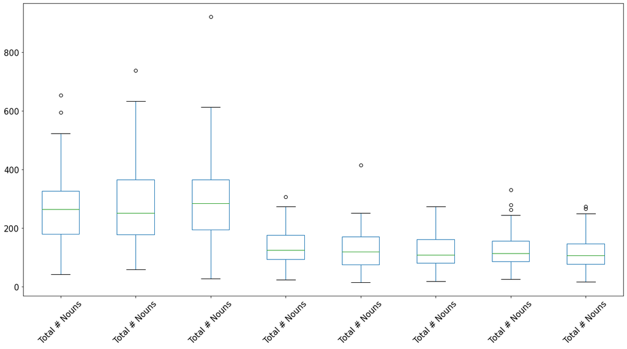

```python
parents_concat.boxplot(column=['Total # Nouns'], grid=False, rot=45, fontsize=15, figsize=(20, 10))
```

## Parent sessions 1-8 boxplots for Total Number of Unique Nouns per 90 minute session

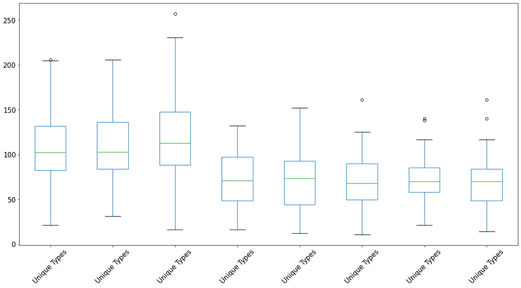

```python
parents_concat.boxplot(column=['Unique Types'], grid=False, rot=45, fontsize=15, figsize=(20, 10))
```

```python
child_concat = pd.concat([df_child_s_1,df_child_s_2,df_child_s_3,df_child_s_4,
          df_child_s_5, df_child_s_6, df_child_s_7,df_child_s_8], axis =1)
```

## Child sessions 1-8 boxplots for Total Number of Nouns per 90 minute session

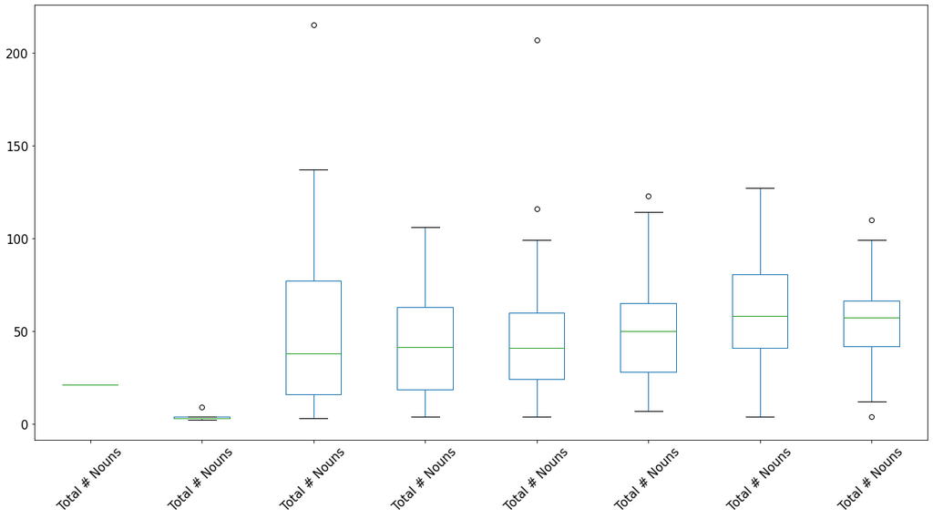

```python
child_concat.boxplot(column=['Total # Nouns'], grid=False, rot=45, fontsize=15, figsize=(20, 10))
```

## Child sessions 1-8 boxplots for Unique Number of Nouns per 90 minute session

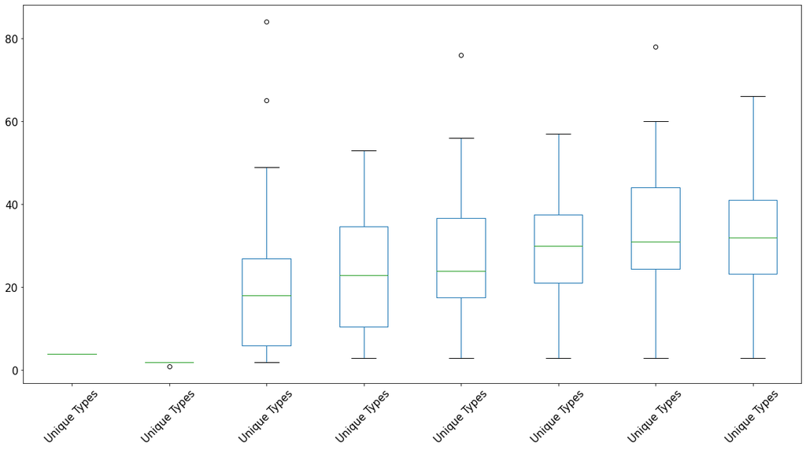

```python
child_concat.boxplot(column=['Unique Types'], grid=False, rot=45, fontsize=15, figsize=(20, 10))
```

## NUMBER OF PARENT NPS SESSIONS 1-3 PREDICTING CHILD NPS SESSIONS 4-8

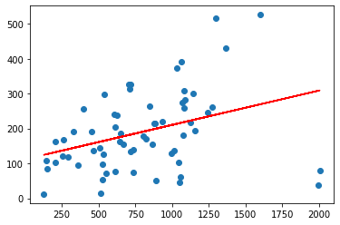

```python
from sklearn.linear_model import LinearRegression
import matplotlib.pyplot as plt

X = df_parent_1_3.iloc[:, 2].values.reshape(-1, 1)  # dfiloc[:, 2] is the column of X
Y = df_child_4_8.iloc[:, 2].values.reshape(-1, 1)  # df.iloc[:, 2] is the column of Y
linear_regressor = LinearRegression()
linear_regressor.fit(X, Y)
Y_pred = linear_regressor.predict(X)

plt.scatter(X, Y)
plt.plot(X, Y_pred, color='red')
plt.plot(figsize=(20, 10))
plt.show()
```

## NUMBER OF UNIQUE PARENT NPS SESSIONS 1-3 PREDICTING CHILD NPS SESSIONS 4-8

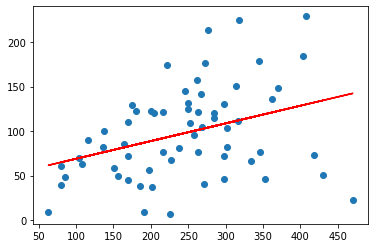

```python
X = df_parent_1_3.iloc[:, 1].values.reshape(-1, 1)  # dfiloc[:, 1] is the column of X
Y = df_child_4_8.iloc[:, 1].values.reshape(-1, 1)  # df.iloc[:, 1] is the column of Y
linear_regressor = LinearRegression()
linear_regressor.fit(X, Y)
Y_pred = linear_regressor.predict(X)

plt.scatter(X, Y)
plt.plot(X, Y_pred, color='red')
plt.show()
```

## PARENT NPS TOKEN-TYPE RATIO SESSIONS 1-3 PREDICTING CHILD NPS SESSIONS 4-8

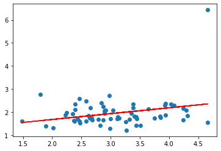

```python
X = df_parent_1_3.iloc[:, 4].values.reshape(-1, 1)  # dfiloc[:, 4] is the column of X
Y = df_child_4_8.iloc[:, 4].values.reshape(-1, 1)  # df.iloc[:, 4] is the column of Y
linear_regressor = LinearRegression()
linear_regressor.fit(X, Y)
Y_pred = linear_regressor.predict(X)

plt.scatter(X, Y)
plt.plot(X, Y_pred, color='red')
plt.show()
```

```python
df_child_4_8
```

|  | Subject | Unique Types | Total # Nouns | Bias | Token/Type Ratio | Observed | Expected |
| --- | --- | --- | --- | --- | --- | --- | --- |
| 0 | 22 | 177 | 326 | 0.914110 | 1.841808 | 0.112994 | 0.083507 |
| 1 | 24 | 145 | 327 | 0.911315 | 2.255172 | 0.131034 | 0.106085 |
| 2 | 25 | 68 | 163 | 0.901840 | 2.397059 | 0.147059 | 0.133485 |
| 3 | 27 | 51 | 79 | 0.936709 | 1.549020 | 0.078431 | 0.064608 |
| 4 | 28 | 73 | 182 | 0.862637 | 2.493151 | 0.205479 | 0.170678 |
| 5 | 29 | 225 | 515 | 0.900971 | 2.288889 | 0.142222 | 0.109253 |
| 6 | 33 | 81 | 178 | 0.938202 | 2.197531 | 0.111111 | 0.086070 |
| 7 | 37 | 96 | 156 | 0.961538 | 1.625000 | 0.062500 | 0.042784 |
| 8 | 38 | 104 | 215 | 0.874419 | 2.067308 | 0.144231 | 0.129189 |
| 9 | 39 | 123 | 265 | 0.883019 | 2.154472 | 0.162602 | 0.125224 |
| 10 | 40 | 109 | 155 | 0.961290 | 1.422018 | 0.055046 | 0.036998 |
| 11 | 42 | 76 | 139 | 0.920863 | 1.828947 | 0.118421 | 0.087198 |
| 12 | 43 | 142 | 313 | 0.942492 | 2.204225 | 0.084507 | 0.076326 |
| 13 | 44 | 85 | 145 | 0.924138 | 1.705882 | 0.129412 | 0.077850 |
| 14 | 45 | 174 | 299 | 0.936455 | 1.718391 | 0.103448 | 0.063038 |
| 15 | 47 | 121 | 186 | 0.940860 | 1.537190 | 0.090909 | 0.055813 |
| 16 | 48 | 115 | 217 | 0.930876 | 1.886957 | 0.113043 | 0.077333 |
| 17 | 49 | 82 | 134 | 0.902985 | 1.634146 | 0.121951 | 0.089591 |
| 18 | 50 | 148 | 309 | 0.899676 | 2.087838 | 0.114865 | 0.107088 |
| 19 | 51 | 120 | 205 | 0.897561 | 1.708333 | 0.141667 | 0.092424 |
| 20 | 54 | 179 | 301 | 0.903654 | 1.681564 | 0.122905 | 0.082773 |
| 21 | 55 | 61 | 85 | 0.964706 | 1.393443 | 0.049180 | 0.034714 |
| 22 | 58 | 125 | 219 | 0.931507 | 1.752000 | 0.112000 | 0.070724 |
| 23 | 59 | 63 | 122 | 0.950820 | 1.936508 | 0.079365 | 0.065198 |
| 24 | 61 | 90 | 168 | 0.898810 | 1.866667 | 0.100000 | 0.103681 |
| 25 | 62 | 77 | 128 | 0.890625 | 1.662338 | 0.142857 | 0.099858 |
| 26 | 64 | 9 | 12 | 0.833333 | 1.333333 | 0.222222 | 0.133016 |
| 27 | 65 | 151 | 258 | 0.949612 | 1.708609 | 0.086093 | 0.053487 |
| 28 | 66 | 123 | 240 | 0.887500 | 1.951220 | 0.146341 | 0.111294 |
| 29 | 68 | 45 | 71 | 0.971831 | 1.577778 | 0.044444 | 0.033065 |
| 30 | 72 | 105 | 195 | 0.938462 | 1.857143 | 0.104762 | 0.070581 |
| 31 | 73 | 129 | 256 | 0.863281 | 1.984496 | 0.162791 | 0.127366 |
| 32 | 74 | 82 | 192 | 0.911458 | 2.341463 | 0.109756 | 0.118547 |
| 33 | 75 | 229 | 526 | 0.884030 | 2.296943 | 0.179039 | 0.121291 |
| 34 | 76 | 7 | 45 | 0.911111 | 6.428571 | 0.285714 | 0.385014 |
| 35 | 77 | 39 | 108 | 0.888889 | 2.769231 | 0.153846 | 0.178985 |
| 36 | 79 | 131 | 281 | 0.875445 | 2.145038 | 0.137405 | 0.128739 |
| 37 | 80 | 50 | 136 | 0.889706 | 2.720000 | 0.200000 | 0.169222 |
| 38 | 81 | 72 | 126 | 0.920635 | 1.750000 | 0.097222 | 0.084201 |
| 39 | 82 | 121 | 238 | 0.878151 | 1.966942 | 0.157025 | 0.118425 |
| 40 | 83 | 46 | 74 | 0.945946 | 1.608696 | 0.086957 | 0.059586 |
| 41 | 84 | 41 | 50 | 0.980000 | 1.219512 | 0.024390 | 0.017898 |
| 42 | 85 | 23 | 38 | 0.921053 | 1.652174 | 0.086957 | 0.088284 |
| 43 | 87 | 48 | 102 | 0.950980 | 2.125000 | 0.083333 | 0.073335 |
| 44 | 88 | 110 | 192 | 0.911458 | 1.745455 | 0.127273 | 0.086239 |
| 45 | 89 | 70 | 119 | 0.949580 | 1.700000 | 0.085714 | 0.057605 |
| 46 | 91 | 136 | 245 | 0.902041 | 1.801471 | 0.125000 | 0.092738 |
| 47 | 92 | 214 | 391 | 0.918159 | 1.827103 | 0.121495 | 0.078152 |
| 48 | 100 | 132 | 274 | 0.843066 | 2.075758 | 0.219697 | 0.143999 |
| 49 | 102 | 111 | 261 | 0.938697 | 2.351351 | 0.108108 | 0.087793 |
| 50 | 103 | 184 | 431 | 0.877030 | 2.342391 | 0.173913 | 0.132063 |
| 51 | 105 | 77 | 137 | 0.897810 | 1.779221 | 0.129870 | 0.101766 |
| 52 | 106 | 46 | 60 | 0.933333 | 1.304348 | 0.086957 | 0.056475 |
| 53 | 107 | 157 | 373 | 0.868633 | 2.375796 | 0.210191 | 0.142547 |
| 54 | 108 | 120 | 215 | 0.916279 | 1.791667 | 0.116667 | 0.084046 |
| 55 | 109 | 66 | 171 | 0.918129 | 2.590909 | 0.151515 | 0.126916 |
| 56 | 110 | 9 | 15 | 0.933333 | 1.666667 | 0.111111 | 0.081328 |
| 57 | 119 | 72 | 103 | 0.980583 | 1.430556 | 0.027778 | 0.020708 |
| 58 | 123 | 38 | 54 | 0.944444 | 1.421053 | 0.052632 | 0.053953 |
| 59 | 124 | 37 | 77 | 0.948052 | 2.081081 | 0.081081 | 0.077012 |
| 60 | 125 | 100 | 162 | 0.938272 | 1.620000 | 0.100000 | 0.062098 |
| 61 | 126 | 59 | 95 | 0.936842 | 1.610169 | 0.067797 | 0.066301 |
| 62 | 127 | 56 | 98 | 0.887755 | 1.750000 | 0.071429 | 0.111395 |